# Газар чөлөөлөлтийн системийн тайлан

### 9.5.3 УБЕГ-ийн газар өмчлөлийн бүртгэл (2.8.1)

**Байрлал:** “Эзэмшигч” таб. **Эх сурвалж:** ХУР (XYP) гарц.

Улсын бүртгэлийн ерөнхий газрын (УБЕГ) газар өмчлөлийн бүртгэлийг ХУР-ын гарцаар нэгж талбарын дугаараар татна: `GET {XYP_BASE_URL}/xyp/ownership/citizen/parcel?parcel_id=…`. Дуудалт нь “Нэгж талбарын мэдээлэл дуудах” цонхны **“Бусад”** бүлгийн “УБЕГ мэдээлэл татах” алхмаар, эсвэл “Эзэмшигч” табын **“Шинэчлэх”** товчоор явна.

- **Харагдац:** Өмчлөгчийн нэр, регистр, эрхийн төрөл, өмчлөх талбай, бүртгэлийн дугаар/огноо. Мөрүүд **бүртгэлийн огноогоор бүлэглэгдэж** шинээс хуучин руу эрэмбэлэгдэнэ (YYYYMMDD хэлбэрийн огноо уншигдаж форматлагдана).
- **Хадгалалт:** Мэдээлэл `parcel_ownership` хүснэгтэд хадгалагдана. Синхрончлол бүрт тухайн талбарын мөрүүд **бүхэлдээ орлуулагдана** (устгаад дахин бичих) тул УБЕГ-ийн бүртгэлтэй яг тохирно. Мөрийн дугаар (`item_no`) талбар тус бүрт давхардахгүй.
- **Гарц тохируулаагүй бол:** Систем “тохируулаагүй” гэсэн тодорхой алдаа буцаах бөгөөд хоосон мэдээлэл хадгалахгүй. Клиентийн хугацаа 20 сек буюу frontend-ийн 30 сек-ээс бага тул хүлээлт цонхонд зөв харагдана.

### 9.5.4 Мэдэгдэл, албан бичгийг имэйл ба E-Mongolia-гаар хүргүүлэх (2.4.2.2, 2.4.2.3, 2.8.5)

**Байрлал:** “Эзэмшигч” табын “Эзэмшигч, өмчлөгч” хэсгийн толгой дахь “Мэдэгдэх хуудас илгээх” товч. **Эрх:** системийн администратор (2026-09-13-аас).

“Эзэмшигч” табд **нэг товч** байрлана. Дарахад цонх нээгдэж, **дээд талд “Шинээр илгээх”** хэсэг (сувгийн сонголттой), доор нь **илгээсэн түүх** огноотойгоор харагдана. Түүх нь хоёр сувгийн бичлэгийг нэгтгэж, шинээс хуучин руу эрэмбэлнэ.

[output not shown]

**Албан бичиг хүргүүлэх (2.4.2.3):** Нөлөөлөлд өртсөн иргэн, хуулийн этгээдэд мэдэгдэл, албан бичиг хүргүүлэх хэсэг систем талаасаа бүрэн хийгдсэн. Үүнд загвараас баримт үүсгэх (иргэн, байгууллагын хувилбар), илгээхийн өмнө дэлгэцэд шалгах, хүлээн авагчийг бүртгэлээс санал болгох, имэйл ба E-Mongolia сувгаар хүргүүлэх, илгээлт бүрийг огноо, төлөвтэй нь бүртгэх үйлдлүүд багтана. Хүргүүлэх суваг бүр бие даасан холбогч хэлбэрээр хийгдсэн тул ашиглалтын явцад шинэ албан бичгийн загвар нэмэх, цахим албан хэрэг хөтлөлт, SMS зэрэг бусад системтэй хүссэнээр холбож ажиллуулах боломжтой.

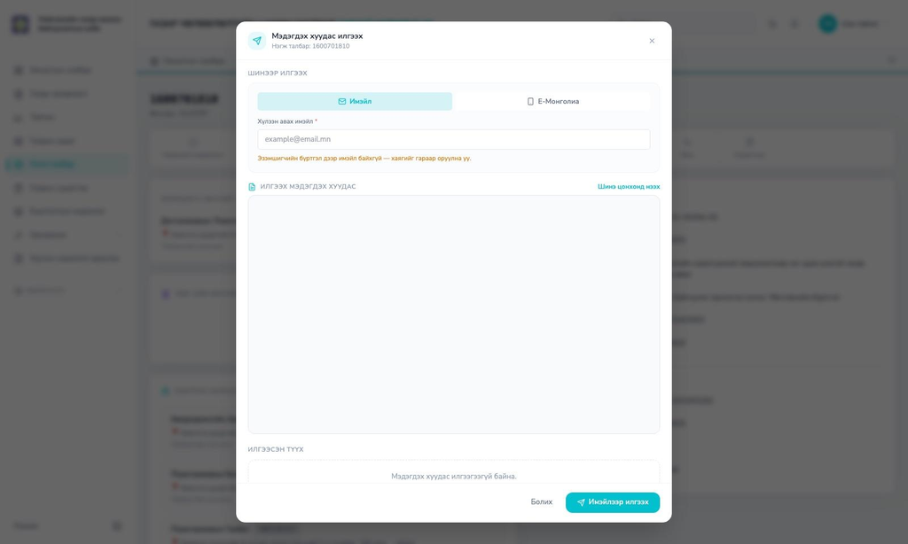

*Зураг 32. “Мэдэгдэх хуудас илгээх” цонх: суваг сонгох, PDF урьдчилан харах, илгээсэн түүх*

### 9.5.5 Төсөөллийн үнэлгээ

**Байрлал:** “Ерөнхий мэдээлэл” таб, “Төсөөллийн үнэлгээ” мөрийн “Үнэлгээ оруулах / Үнэлгээ тохируулах” товч. **Эрх:** дотоод ажилтан, түгжигдсэн нэгж талбарт засахгүй.

Албан ёсны үнэлгээ хийгдэхээс өмнө нэгж талбарын нөхөх олговрын урьдчилсан дүнг тооцож, төсөв төлөвлөлтөд ашиглах зориулалттай.

- **Тооцоо:** Газрын суурь төлбөр, жишиг үнэ болон итгэлцүүрээр тооцно. Өмчлөх эрхтэй газарт итгэлцүүр хэрэглэхгүй.
- **Хавсралт:** Тооцооны үндэслэл болох баримтыг хавсаргана.
- **Түүх:** Өөрчлөлт бүр хэн, хэзээ оруулснаар хадгалагдаж, “Түүх” цонхоор харагдана. Утгыг арилгах боломжтой.

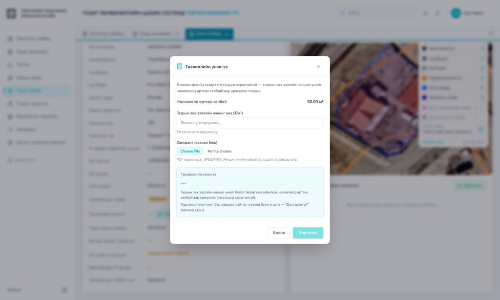

*Зураг 33. Төсөөллийн үнэлгээ оруулах цонх*

### 9.5.6 Трас зураг хэвлэх

**Байрлал:** “Ерөнхий мэдээлэл” табын байршлын зургийн “Трас зураг” товч. **Эрх:** системийн администратор эсвэл тухайн чөлөөлөлтөд хуваарилагдсан ажилтан.

Нэгж талбарын хил, хэмжээ, хөрш нэгж талбаруудыг харуулсан трас зургийг стандарт хуудсаар PDF болгон хэвлэнэ. Хэвлэсэн файл нь нэгж талбарын “Трас зураг” хавсралт болж автоматаар хадгалагдана.

- **Тохиргоо:** “Гарчиг” (анхдагчаар чөлөөлөлт ба нэгж талбарын нэрээр бөглөгдөж, засаж болно), “Цаас” (A4, A3), “Чиглэл” (босоо, хэвтээ), жижиг зургийн байрлал, “Ерөнхий тоймын масштаб” (автомат эсвэл кадастрын түгээмэл масштабууд), “Ерөнхий тоймын давхарга” (нэгж талбарын төлөв, төлөвлөгөөний хил, захиргааны нэгжийн давхаргуудыг сонгох).
- **Агуулга:** Нэгж талбарын хил, хэмжээ, “Байршил” газрын зурагт асаалттай давхаргуудаар бэлдсэн жижиг байршлын зураг.
- **Үйлдэл:** “Зураг үүсгэх” товчоор урьдчилан харж, “Хэвлэх” товчоор PDF татна. Хэвлэхэд нэгж талбарын “Трас зураг” хавсралт шинэ файлаар солигдоно.

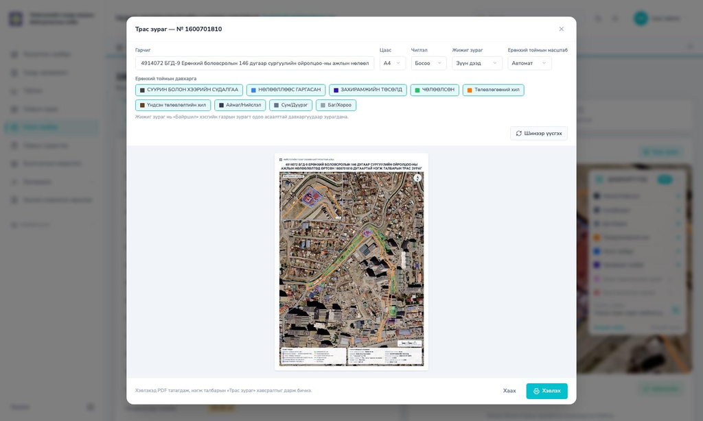

*Зураг 34. Трас зураг хэвлэх цонх: урьдчилан харах, масштаб, гарчиг*

### 9.6 Захирамжийн төслийн модуль

**Цэс:** “Захирамж” цэсийн “Захирамжийн төсөл”, “Шийдвэр”. **Зам:** `/decision_draft`, `/decision_draft/[id]`, `/decision`, `/decision/[id]`. **Эрх:** `decision:read|create|update|delete`.

**Зорилго.** Нөхөх олговор олгох захирамжийн төслийг бэлтгэж, санхүүжилттэй уялдуулан нэгж талбаруудыг холбох, хянуулах явцыг бүртгэж, баталгаажсан шийдвэрийг тусад нь хөтлөх.

Нөхөх олговрын захирамжийн төслийг бэлтгэх, санхүүжилттэй уялдуулах, нэгж талбар холбох, явц бүртгэж батлах бие даасан модуль. Газрын эрх (`land:*`) энд хүчингүй. Модуль тусдаа эрхийн бүлэгтэй тул захирамжтай ажилладаг мэргэжилтэн зөвхөн энэ модульд хандана. Гадаад ролиуд (мэргэжлийн байгууллага, МИКА, санхүү) эрх санамсаргүй олгогдсон ч энэ модульд хүрэхгүй.

[output not shown]

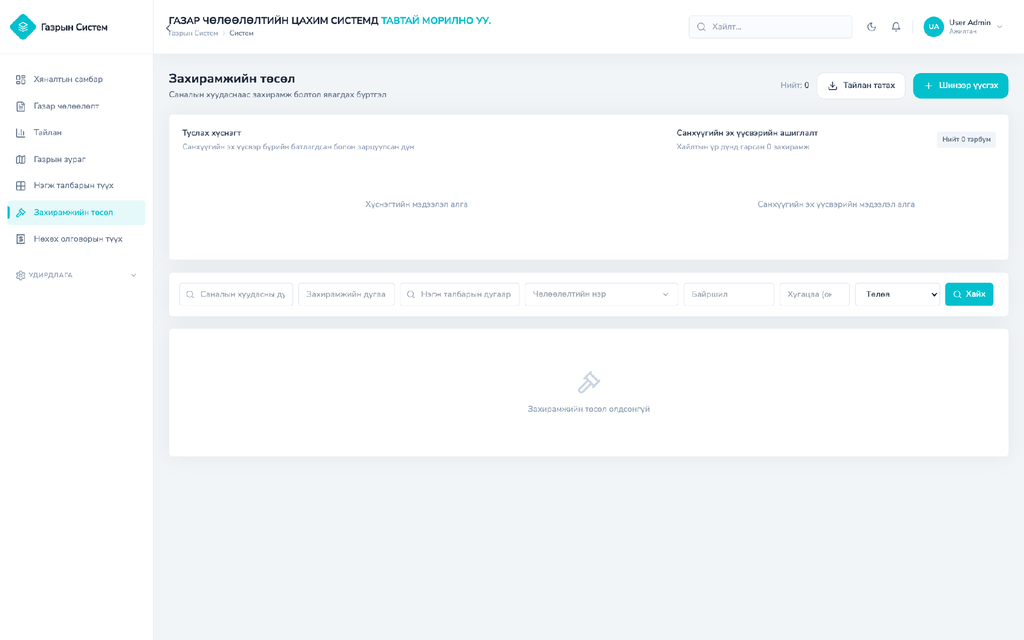

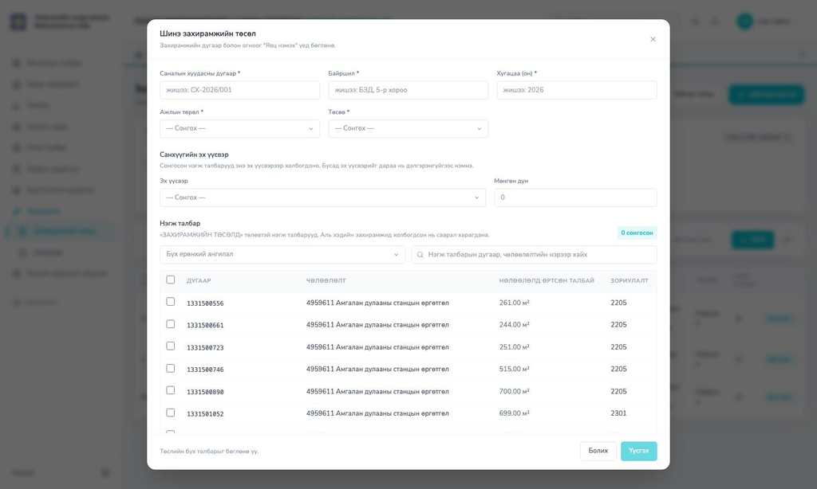

*Зураг 36. Шинэ захирамжийн төсөл үүсгэх: нэгж талбар сонгох, санхүүжилтийн үлдэгдэл*

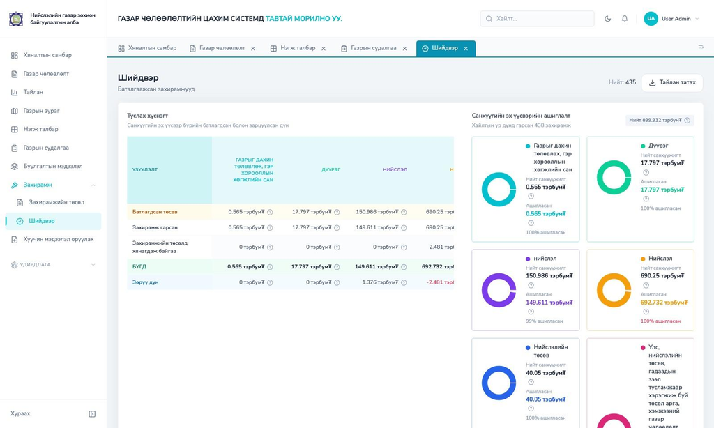

*Зураг 37. “Шийдвэр”: баталгаажсан захирамжуудын жагсаалт ба санхүүжилтийн хураангуй*

### 9.7 Нөхөх олговрын түүх

**Зам:** `/compensation`, `/compensation/[id]`

**Зорилго.** Бүх нэгж талбарын нөхөх олговрыг нэгдсэн жагсаалтаар харах, хэвлэхэд бэлэн баримт хэлбэрээр гаргах.

2026-10-21-ээс “Нөхөх олговрын түүх” хажуугийн цэсээс хасагдсан: олговрын мэдээллийг нэгж талбарын “Нөхөх олговор” таб, “Тайлан”, “Шийдвэр” жагсаалтаас харах болсон. Дэлгэц өөрөө хэвээр байгаа бөгөөд холбоосоор нээгдэнэ.

- **Статистик:** Нийт, Батлагдсан, Хүлээгдэж буй, Татгалзсан тоон картууд.
- **Харагдах мэдээлэл:** Нэгж талбар (линк), Эзэмшигч (+чөлөөлөлтийн нэр), Регистр, Хэлбэр (Мөнгөн/Газраар), Дүн, Огноо, Төлөв.
- **Шүүлтүүр:** Талбарын дугаар/эзэмшигчээр хайх, чөлөөлөлт, олговрын хэлбэр, төлөвөөр шүүх.
- **Дэлгэрэнгүй:** Дэлгэрэнгүй нь “Хэвлэх” товчтой, хэвлэхэд бэлэн баримт хэлбэртэй. Олговор бүртгэх үйлдэл талбарын “Нөхөх олговор” табаас хийгдэнэ.

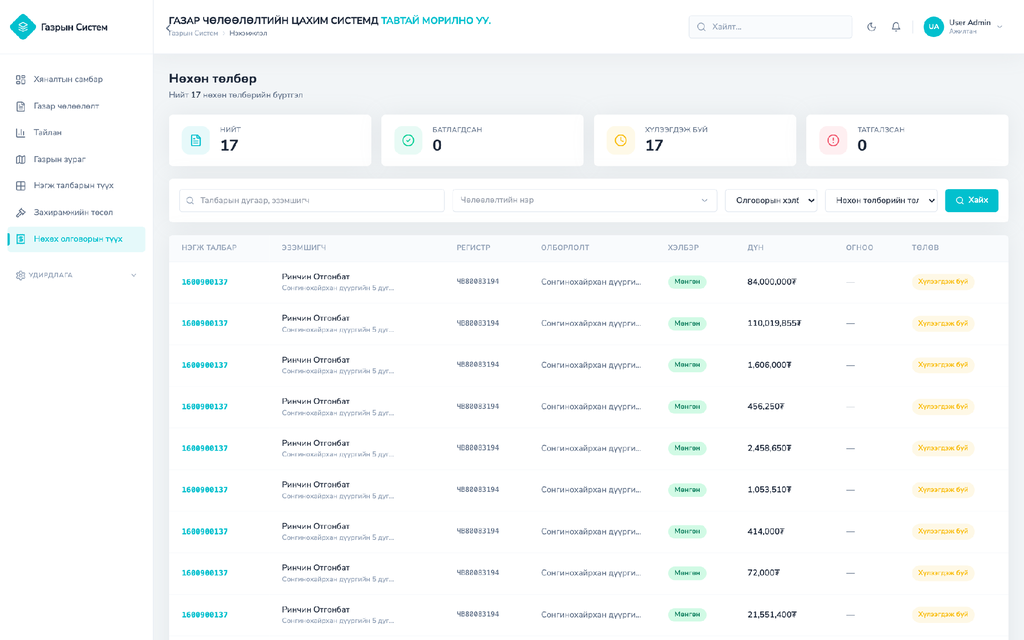

*Зураг 38. Нөхөх олговрын нэгдсэн жагсаалт: статистик картууд, шүүлтүүр, төлөвийн тэмдэглэгээ*

### 9.8 Тайлан

**Зам:** `/report`. **Хандах:** зөвхөн ахлах мэргэжилтэн, администратор (backend `/users/me`-ээр шалгана).

**Зорилго.** Нөхөх олговортойгоор чөлөөлсөн газрын мэдээллийг ГЧХ маягтын дагуу шүүлтүүрээр нэгтгэн харж, Excel тайлан татах.

- **Харагдах мэдээлэл:** Нэгж талбарын дугаар, чөлөөлөлт, төлөвлөгөө, ангилал, өмчлөгч, регистр, талбай, чөлөөлөх талбай, эрхийн төрөл, нөхөн төлбөрийн дүн.
- **Шүүлтүүр:** Төлөвлөгөө, чөлөөлөлт, он (2010 оноос хойш олон сонголт), эрхийн төрөл, зориулалт, олговрын хэлбэр, ангиллаар шүүж, баганын гарчгаар эрэмбэлнэ.
- **Статистикийн картууд:** Хяналтын самбартай адил загварын KPI карт (нийт чөлөөлөлт, нэгж талбар, нийт талбай, нөхөх олговрын дүн хэлбэрээр), он ба төлөвөөр задалсан баганан график. Эдгээр нь идэвхтэй шүүлтийн БҮХ (хуудаслаагүй) үр дүнгээр тооцогдоно.
- **Excel экспорт:** “Тайлан татах” товчоор Excel файлыг сервер талд загвараас үүсгэн, явцын мэдээллийг бодит цагт (N/нийт) харуулж татна (SSE стрийм).

*Гүйцэтгэлийн засвар:* Статистикийн картуудыг өмнө нь хуудаслагдсан жагсаалтын бүх хуудсыг дараалан татаж клиент талд нэгтгэдэг байсан нь том жагсаалтад `/report/download`-ыг 10 гаруй удаа давхар дуудуулж байв. Үүнийг сервер талд нэг л дуудлагаар нэгтгэн тооцдог шинэ `GET /report/summary` endpoint болгож зассан.

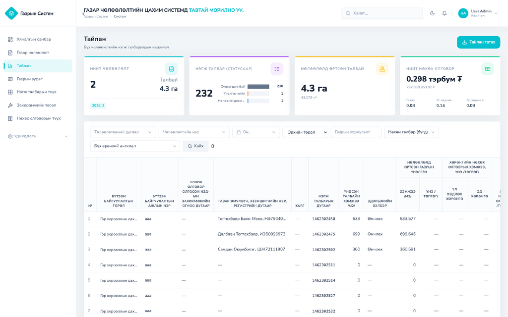

### 9.9 Газрын зураг

**Зам:** `/map` (мөн чөлөөлөлтийн “Байршил” таб, хяналтын самбарын зураг)

**Зорилго.** Захиргааны нэгж, төлөвлөгөө, чөлөөлөлт, нэгж талбар болон ГУС-ийн давхаргуудыг нэг газрын зураг дээр давхарлан харах, объектын мэдээлэлтэй танилцах.

- **Захиргааны давхаргууд:** Аймаг/Нийслэл, Сум/Дүүрэг, Баг/Хороо
- **Төлөвлөлт, чөлөөлөлтийн давхаргууд:** Үндсэн төлөвлөлтийн хил, Төлөвлөгөөний хил, Чөлөөлөх талбай, Барилгын хил
- **Нэгж талбарын давхаргууд:** “Нэгж талбарын хил” давхарга ба түүний **дэд давхаргууд**. Нэгж талбарын төлөв бүр тусдаа дэд давхарга болж, “Нэгж талбарын статус” тохиргоонд заасан өнгөөр зурагдана.
- **ГУС-ийн давхаргууд:** “Шинэ зөвшилцсөн зураг” (барилга байгууламж, авто зам, цахилгаан, ус хангамж, ариутгах татуурга, дулаан, холбооны шугам зэрэг ангиллаар) ба “Хамгаалалтын зурвас” (усан сан, ундны усны эх үүсвэр, ойн сан, цахилгаан ба дулааны шугам, үерийн далан, оршуулгын газар зэрэг 30 гаруй ангилал). Ангилал бүр тусдаа дэд давхарга бөгөөд өөрийн өнгө, зураасан дүүргэлттэй.
- **Дроны ортофото:** Байршуулсан GeoTIFF зураг бүр өөрийн давхаргатай бөгөөд асаах/унтраах боломжтой.
- **Суурь зураг (тохируулж болно):** Давхаргын самбарын доод хэсгийн “Суурь зураг” бүлэгт одоогийн суурь зургийн нэр болон араа (⚙) хэлбэртэй товч (`admin:update` эрхтэйд) байрлана. Хаяг оруулбал бүх хэрэглэгчийн зурагт хэрэгжих ба хоослоход **“Үндсэн суурь зураг”** руу буцна (7.1).
- **Нээлттэй давхарга:** `land:v_parcel_public` нь мөн гадны системд эрх шалгахгүй WMS/WFS-ээр нээлттэй (7.2).
- **Үйлдлүүд:** Давхаргын самбараас асааж/унтраана. Объект дээр дарахад нэгж талбар эсвэл чөлөөлөлтийн мэдээллийн цонх нээгдэнэ. Мөн **2D/3D сонголт** (CesiumJS, одоогийн харагдац, зумыг хадгална), бүтэн дэлгэц, **“Ажлын зураг”** хэвлэх (гарчиг, цаасны хэмжээ, хэвтээ/босоо) үйлдэлтэй.
- **Шүүлт:** Хяналтын самбараас чөлөөлөлт, он, захиргааны нэгж, ажилтнаар CQL шүүлт дамждаг. Он цагийн зураг дээр сонгосон сарын байдлаар төлөвийн давхарга зурагдана (9.1.2).

**Давхаргын өнгө хаанаас тодорхойлогддог вэ:** газрын зураг дээр харагдах бодит өнгө нь GeoServer-ийн SLD загваруудаар (`styles/*.sld`) тодорхойлогдоно. Frontend-ийн `layer-config.ts` нь зөвхөн давхаргын самбар дахь **тайлбарын** өнгө, нэр, эрэмбийг агуулна.

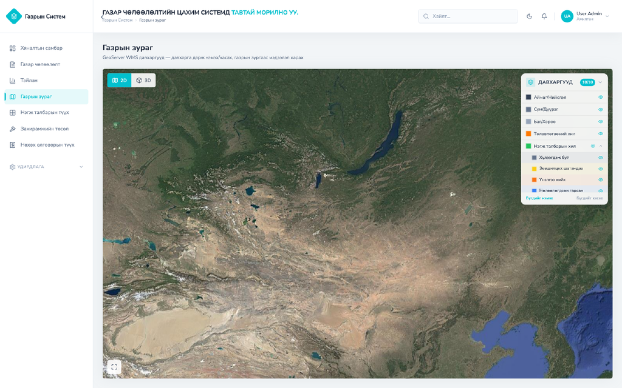

*Зураг 40. Газрын зураг: GeoServer давхаргууд, давхаргын самбар, 2D/3D сонголт, нэгж талбарын статусын өнгөт дүрслэл*

### 9.9.1 Давхаргууд харах

**Байрлал:** газрын зургийн баруун дээд талын “Давхаргууд” самбар (газрын зураг, хяналтын самбар, чөлөөлөлтийн “Байршил” таб, нэгж талбарын байршлын зураг). **Хандах:** дотоод хэрэглэгч

Давхаргын самбар нь газрын зураг дээр ямар мэдээлэл харагдахыг хэрэглэгч өөрөө сонгох хэрэгсэл юм. Толгой хэсэгт асаалттай ба нийт давхаргын тоо (жишээ нь: 14/51) харагдана.

- **Асаах, унтраах:** Давхарга бүрийн нүдэн тэмдгээр харагдацыг асааж, унтраана. “Бүгдийг нэмэх”, “Бүгдийг хасах” товчоор нэг дор удирдана.
- **Дэд давхаргууд:** “Нэгж талбарын хил”, “Шинэ зөвшилцсөн зураг”, “Хамгаалалтын зурвас” давхаргын хажуугийн сумаар дэд давхаргуудын жагсаалтыг дэлгэж, төлөв эсвэл ангилал тус бүрийг тусад нь асааж, унтраана. Өнгийн тайлбар хамт харагдана.
- **Объектын мэдээлэл:** Газрын зураг дээрх нэгж талбар, чөлөөлөлт, ГУС-ийн объект дээр дарахад мэдээллийн цонх нээгдэнэ.
- **Суурь зураг:** Самбарын доод хэсгээс суурь зургийг харах, администратор хаягийг нь солих боломжтой (7.1).
- **Харагдацын горим:** “2D”, “3D”, “Он цагийн зураг” сонголт болон “Дэлгэц дүүргэж харах” товч

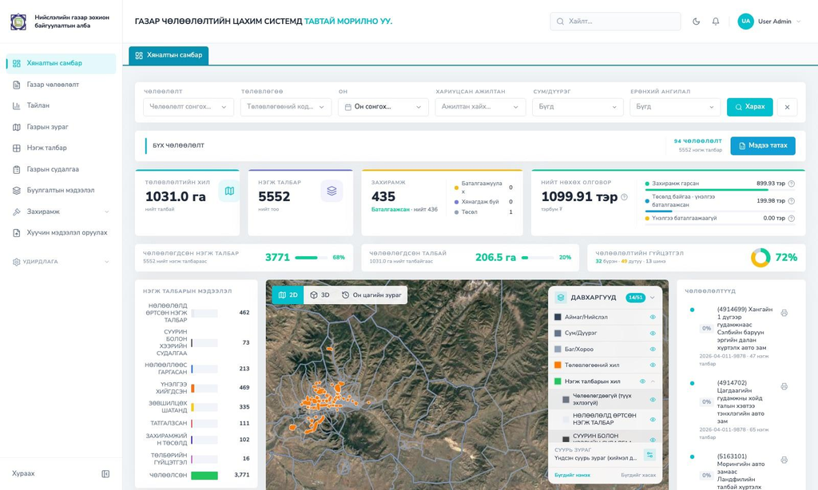

*Зураг 41. Давхаргын самбар: давхарга асаах, унтраах, дэд давхаргуудын жагсаалт*

### 9.9.2 Ажлын зураг хэвлэх

**Байрлал:** газрын зургийн баруун доод талын “Ажлын зураг” товч (чөлөөлөлтийн “Байршил” таб, хяналтын самбар). **Хандах:** дотоод хэрэглэгч

Чөлөөлөлтийн хил, нэгж талбаруудыг төлөвийн өнгө, тайлбартай нь хэвлэх зориулалттай газрын зураг (PDF) бэлтгэнэ. Хээрийн ажил, хурал, албан бичигт хавсаргахад ашиглана.

- **Тохиргоо:** “Гарчиг”, “Цаас” (A3, A4), “Чиглэл” (хэвтээ, босоо) сонголттой бөгөөд хэвлэх давхаргууд ба ГУС-ийн дэд давхаргуудыг сонгоно.
- **Агуулга:** Газрын зураг, төлөв тус бүрийн нэгж талбарын тоо бүхий тайлбар, НИТХ-ын тогтоолын дугаар, масштаб, хойд зүгийн тэмдэг. Эцсийн бус төлөвтэй нэгж талбар дээр өмчлөгчийн нэр бие биетэйгээ давхцахгүйгээр байрлана.
- **Үйлдэл:** “Зураг үүсгэх” товчоор урьдчилан харж, PDF татна.

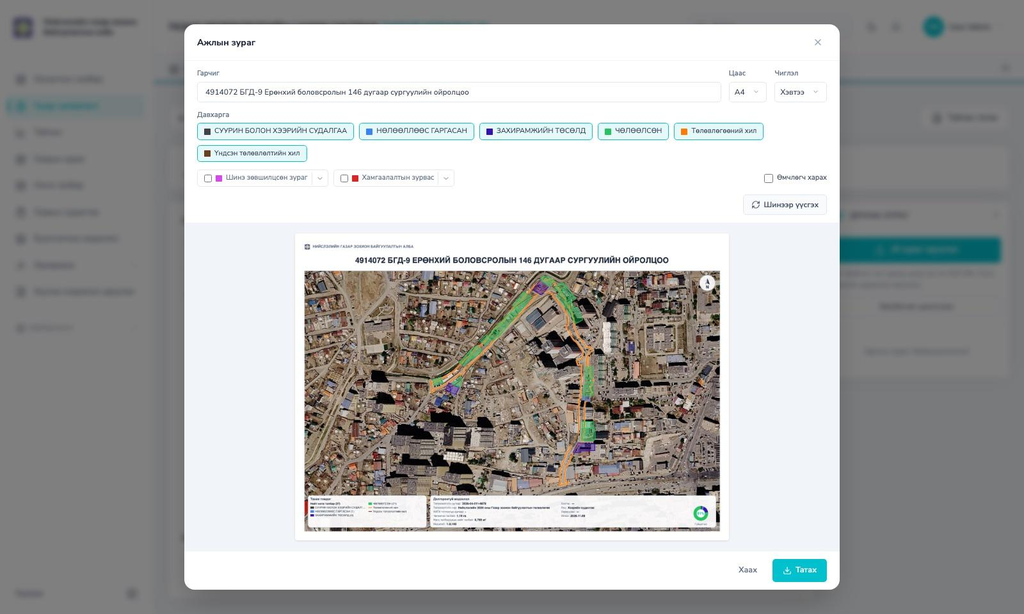

*Зураг 42. “Ажлын зураг” хэвлэх цонх: гарчиг, цаасны хэмжээ, чиглэл, давхарга сонгох, урьдчилан харах*

### 9.10 Хэрэглэгчид ба Эрх & Роль

**Зам:** `/users`, `/roles`. **Эрх:** `users:*`, `roles:*`, `permissions:read`

**Зорилго.** Системийн хэрэглэгчдийг бүртгэх, роль оноох, ролийн зөвшөөрлийг цэс, үйлдэл тус бүрээр тохируулах.

- **Хэрэглэгчид:** Хэрэглэгчийн жагсаалт (нэр, албан тушаал, имэйл, роль, идэвхтэй эсэх). “Нэмэх” маягт нь нэр*, овог*, хэрэглэгчийн нэр*, албан тушаал, имэйл*, роль, нууц үг* талбартай. Мөрийн үйлдлүүд нь “Засах”, нууц үг солих, “Устгах”.
- **Эрх & Роль:** “Роль нэмэх” (нэр*, тайлбар), ролийн “Засах”/“Устгах” үйлдэлтэй. Роль сонгоход цэс тус бүрийн зөвшөөрлүүд бүлэглэгдэн харагдах ба тохируулаад “Хадгалах” товчоор хадгална. Шаардлагагүй цэсийн холбоосыг хасах боломжтой.
- **Эрх нэмэгдүүлэлтээс сэргийлэх:** Өөрийн роль, төлөвийг өөрөө өөрчлөх, өөрийгөө устгах хориотой бөгөөд өөрт байхгүй эрхийг бусдад олгож чадахгүй. Эдгээр шалгалт frontend (`access-policy.ts`) ба backend (`role.go`, `user.go`) дээр давхар хийгдэнэ.
- **Хэлтсээр хязгаарлах:** Хэрэглэгч бүр алба хэлтэстэй холбогдоно. Системийн администратороос бусад хэрэглэгч зөвхөн өөрийн хэлтсийн чөлөөлөлт, нэгж талбар, хэрэглэгчийг харна. “Хэлтсийн дарга” роль нэмэгдсэн.
- **Администраторын тоо:** Системийн администраторын эрхтэй хэрэглэгч гурваас хэтрэхгүй бөгөөд хэтрэх үед систем хадгалахгүй.
- **Жагсаалт:** нэр, роль, төлөвөөр шүүх, баганаар эрэмбэлэх

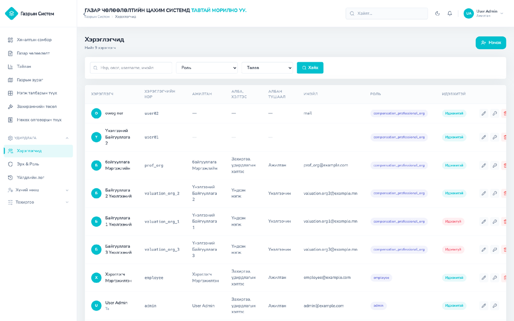

*Зураг 43. Хэрэглэгчийн бүртгэл: хайлт, роль болон төлөвийн шүүлтүүр, мөрийн үйлдлүүд*

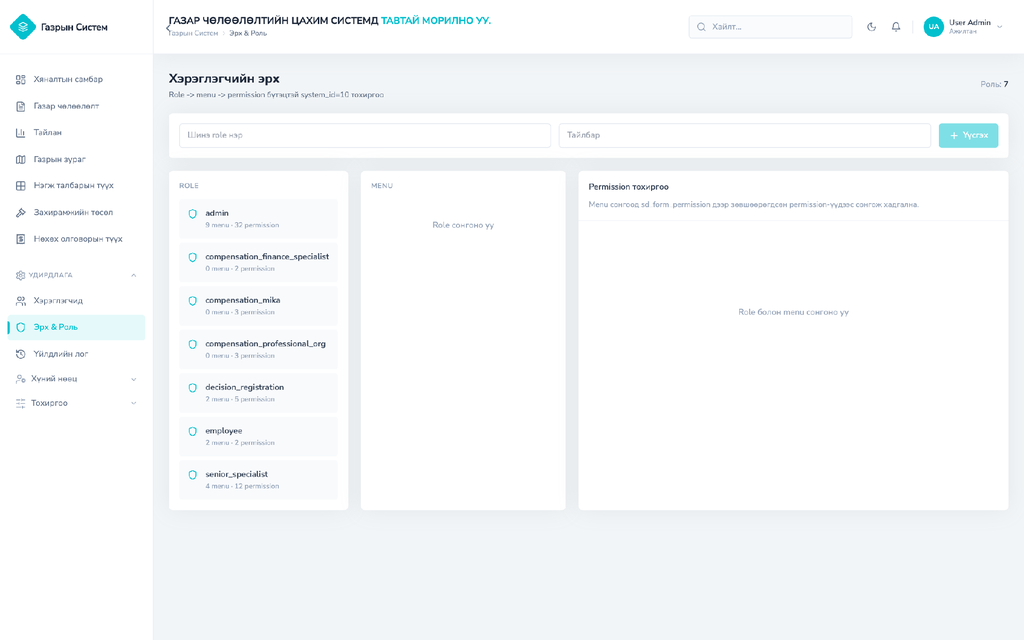

*Зураг 44. Эрх & Роль: ролийн жагсаалт, цэс тус бүрийн зөвшөөрлийн тохиргоо*

### 9.11 Миний чөлөөлөлтүүд (мэргэжлийн байгууллага)

**Зам:** `/my_acquisitions`. **Хандах:** зөвхөн `professional_org` роль

**Зорилго.** Мэргэжлийн (үнэлгээний) байгууллагад зөвхөн өөрт оноогдсон чөлөөлөлтүүдийг харуулж, үнэлгээг нь оруулах боломж олгох.

- **Хязгаарлагдмал жагсаалт:** Зөвхөн өөрийн байгууллагад оноогдсон чөлөөлөлтүүдийг харуулна. Нэрээр хайх, “Дэлгэрэнгүй” (баталгаажсан бол “Хаалттай”) товчтой, үүсгэх/засах үйлдэлгүй.
- **Тусгаарлалт:** Бүх дуудлага `/prof` порталын 51 сувгаар явах ба ерөнхий `/land-acquisitions` сувгуудад хүрэхгүй.

### 9.12 Тохиргооны 10 модуль (администратор)

**Цэс:** “Тохиргоо” (Ерөнхий, Чөлөөлөлт, Нэгж талбар, Үнэлгээ, Захирамжийн төсөл гэсэн 5 бүлэг). **Эрх:** “Админ” роль эсвэл `admin:read|create|update|delete`

Эдгээр 10 дэлгэц нь системийн “тохируулгын самбар” юм: байгууллагын ажлын дүрэм, ангилал, төлөв, урсгал өөрчлөгдөхөд програмист дуудахгүйгээр администратор өөрөө эндээс өөрчилнө. Бүх модуль “Нэмэх”, “Засах”, “Устгах” гэсэн нэгдсэн загвартай. Устгахаас өмнө баталгаажуулах асуулт гарах ба бусад бүртгэлд ашиглагдаж буй утгыг систем устгахгүй. Тохиргооны цэс мэргэжлийн байгууллага, МИКА, санхүүгийн мэргэжилтэнд харагдахгүй. Нэмэх, засах, устгах үйлдэл бүрийг сервер тохирох эрхээр давхар шалгана, харин лавлахын жагсаалтыг бусад дэлгэцийн сонголтод зориулж нэвтэрсэн бүх хэрэглэгч уншина. 2026-10-21-нд “Чөлөөлөлтийн явцын статус” модуль хасагдаж (системд ашиглагддаггүй байсан), “Төсөл хянах нэгж” модуль нэмэгдсэн.

| **Бүлэг** | **Модулиуд** |
| --- | --- |
| **Ерөнхий** | Хавсралтын төрөл |
| **Чөлөөлөлт** | Чөлөөлөлтийн ангилал, Чөлөөлөлтийн ажлын урсгал |
| **Нэгж талбар** | Нэгж талбарын статус, Нэгж талбарын ажлын урсгал |
| **Үнэлгээ** | Байгууламжийн чанарын төрөл, Байгууламжийн тооцооллын төрөл |
| **Захирамжийн төсөл** | Ажлын төрөл, Төсөв, Төсөл хянах нэгж |

### 9.12.1 Хавсралтын төрөл

**Цэс:** “Тохиргоо” цэсийн “Ерөнхий”. **Зам:** `/document_type`

**Зорилго.** Чөлөөлөлт болон нэгж талбарт хавсаргах баримт бичгийн төрлийн лавлахыг бүрдүүлнэ. Энд бүртгэсэн төрөл файл хавсаргах цонхны “Файлын төрөл” сонголтод гарч, “Нэгж талбарын ажлын урсгал”-д шилжилтийн заавал хавсралт болгон сонгогдоно. Жишээ: “Гэрээ” төрлийг “Зөвшилцөх шатанд” төлөвөөс “Захирамжийн төсөлд” төлөв рүү шилжих шилжилтэд заавал болговол гэрээ хавсаргаагүй нэгж талбарыг захирамжийн төсөлд шилжүүлэхгүй.

- **Харагдах мэдээлэл:** Нэр, код, тайлбар, бүртгэсэн огноо ба хэрэглэгч. Хамгийн сүүлд нэмсэн нь эхэнд байрлана.
- **Үйлдлүүд**
  - “Нэмэх” маягтад Төрлийн код*, Нэр*, Тайлбар оруулж, “Үүсгэх” товчоор хадгална.
  - Засах (харандаа) товч “Засварлах” маягтыг нээнэ. Устгах (хогийн сав) товч баталгаажуулах асуулттай.
  - Системийн 6 төрлийг (“Үнэлгээний тайлан”, “Үнэлгээний хүснэгт”, “Ажлын зураг”, “Хурлын тэмдэглэл”, “Нөхөх олговор олгосон баримт”, “Бусад”) устгах, кодыг нь солих боломжгүй, харин нэрийг нь солих боломжтой.
  - Хавсралтад эсвэл урсгалын заавал хавсралтад ашиглагдсан төрлийг устгахгүй бөгөөд хэдэн газар ашиглагдсныг мэдэгдэнэ.

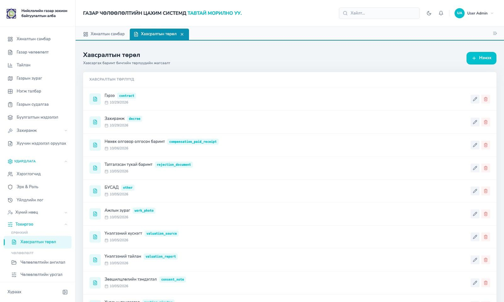

*Зураг 45. Хавсралтын төрөл*

### 9.12.2 Чөлөөлөлтийн ангилал

**Цэс:** “Тохиргоо” цэсийн “Чөлөөлөлт”. **Зам:** `/acquisition_category`

**Зорилго.** Газар чөлөөлөлтийн ерөнхий ангилал ба түүний доторх дэд ангиллын хоёр шатлалт лавлах. Чөлөөлөлт бүртгэхэд ангилал заавал сонгогдож, жагсаалт ба тайлангийн “Ангилал” шүүлтүүрт ашиглагдана. Ерөнхий ангилалд “Хариуцсан алба” оноох нь мэдээлэл харах хүрээг тодорхойлно: администратороос бусад ажилтан зөвхөн өөрийн албанд оноогдсон ангиллын чөлөөлөлтийг харна. Жишээ: “Авто зам” ангиллыг нэг албанд оноовол тэр ангиллын чөлөөлөлтүүд зөвхөн тухайн албаны ажилтан болон администраторт харагдана.

- **Харагдах мэдээлэл:** Зүүн талд ерөнхий ангиллын жагсаалт (нэр, дэд ангиллын тоо, холбогдсон чөлөөлөлтийн тоо), баруун талд сонгосон ангиллын нэр, эрэмбэ, хариуцсан алба, дэд ангиллууд (“N чөлөөлөлт” тэмдэглэгээтэй).
- **Үйлдлүүд**
  - “Ерөнхий ангилал нэмэх” маягт: Нэр*, Хариуцсан алба, Эрэмбэ. “Засах” товчоор нэр, алба, эрэмбийг засна.
  - “Дэд ангилал нэмэх” маягт: Нэр*, Эрэмбэ. Харандаа товчоор засна.
  - Чөлөөлөлт холбогдсон ангиллыг устгахгүй (“…-д N чөлөөлөлт холбогдсон тул устгах боломжгүй”). Ерөнхий ангиллыг устгахад дэд ангиллууд хамт устах тул баталгаажуулах цонхонд тоог нь харуулна.

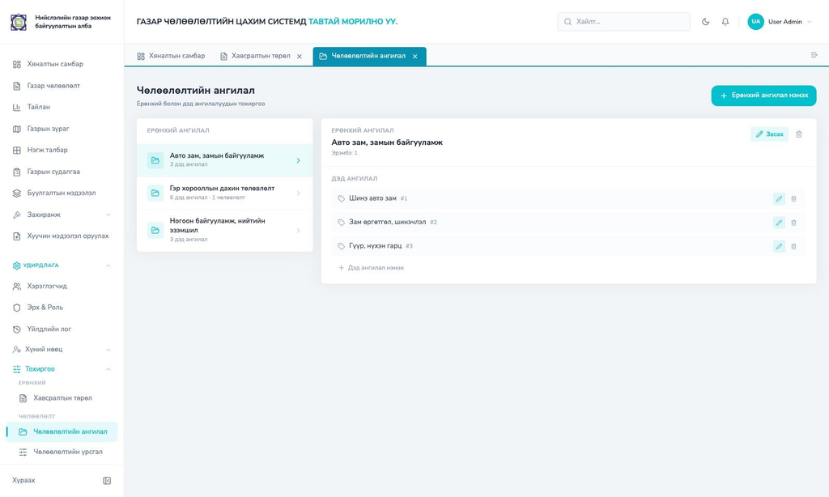

*Зураг 46. Чөлөөлөлтийн ангилал: ерөнхий ба дэд ангилал, хариуцсан алба*

### 9.12.3 Чөлөөлөлтийн ажлын урсгал

**Цэс:** “Тохиргоо” цэсийн “Чөлөөлөлт”. **Зам:** `/acquisition_workflow`

**Зорилго.** Чөлөөлөлтийн төлөвүүдийн (Шинэ, Хээрийн судалгаа, Баталгаажсан, Цуцлагдсан) хооронд аль шилжилтийг зөвшөөрөхийг тохируулна. Чөлөөлөлтийн “Явц” табын “Явц солих” цонхонд зөвхөн тохируулсан шилжилтүүд санал болгогдох ба тохируулаагүй шилжилтийг сервер хүлээж авахгүй. Тохиргооноос үл хамааран “Хээрийн судалгаа” руу шилжихэд нэгж талбар бүрдсэн, давхцалгүй байх, “Баталгаажсан” руу шилжихэд бүх нэгж талбар эцсийн төлөвт байх шаардлага үйлчилнэ. Жишээ: “Хээрийн судалгаа” төлөвөөс “Цуцлагдсан” төлөв рүү шилжих шилжилт нэмбэл судалгааны шатнаас чөлөөлөлтийг цуцлах боломжтой болно.

- **Харагдах мэдээлэл:** Эхлэх төлөвөөр бүлэглэсэн “Тохируулсан шилжилтүүд”, очих төлөв ба эрэмбийн дугаар, мөн “Статусын лавлах”.
- **Үйлдлүүд**
  - “Шилжилт нэмэх” хэсэг: Эхлэх статус, Очих статус*, Эрэмбэ
  - Шилжилтийг устгаад дахин нэмж өөрчилнө

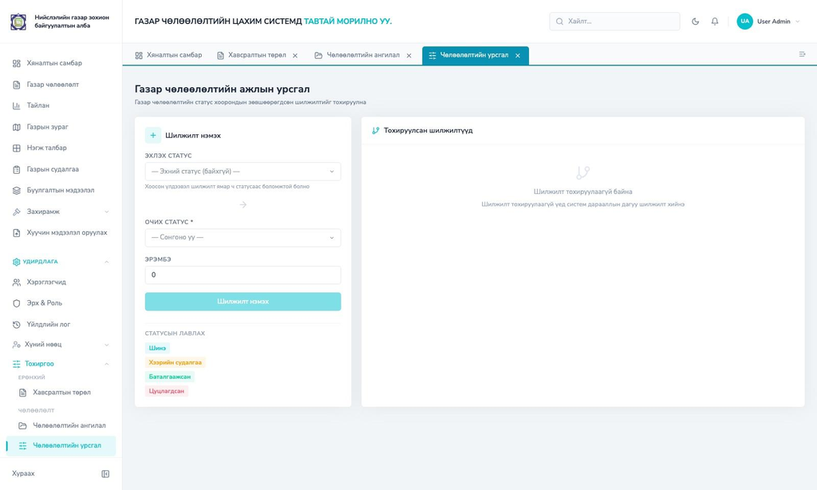

*Зураг 47. Чөлөөлөлтийн ажлын урсгал: төлөв хоорондын шилжилтүүд*

### 9.12.4 Нэгж талбарын статус

**Цэс:** “Тохиргоо” цэсийн “Нэгж талбар”. **Зам:** `/parcel_status`

**Зорилго.** Нэгж талбарын төлөвүүдийг (нэр, эрэмбэ, өнгө) болон төлөв бүрийн дүрмийг тохируулна. Өнгө нь бүх жагсаалтын төлөвийн тэмдэглэгээ, газрын зургийн нэгж талбарын давхарга, хэвлэх зурагт нэгэн адил хэрэглэгдэнэ. Жишээ: “Төлбөрийн гүйцэтгэл” төлөвийн өнгийг солиход тэр төлөвтэй нэгж талбарууд газрын зураг дээр шинэ өнгөөр харагдана.

- **Харагдах мэдээлэл:** Өнгөт тэмдэг, төлөвийн нэр, код, эрэмбэ, идэвхтэй дүрмийн тэмдэглэгээнүүд. Үндсэн 9 төлөв 101-109 кодтой, шинэ төлөв 110-аас эхлэн автоматаар код авна.
- **Үйлдлүүд**
  - “Нэмэх” маягт: Нэр*, Эрэмбэ, Өнгө (өнгө сонгогч эсвэл #rrggbb), “Дүрэм” хэсгийн тэмдэглэгээ. Засах, устгах боломжтой (ашиглагдаж буй төлөвийг устгахгүй).
  - **Дүрмүүд:** “Эцсийн төлөв” дүрмээр нэгж талбарын мэдээлэл, эзэмшигч, хавсралт, санхүүгийн засвар түгжигдэж, чөлөөлөлтийн явцын хувьд тооцогдоно. “Явц түгжих” дүрмээр энэ төлөвөөс цааш төлөв солихгүй. “Үнэлгээний шат” дүрмээр мэргэжлийн байгууллага, МИКА энэ төлөвтэй нэгж талбарыг харж үнэлгээ оруулах ба шилжихэд “Үнэлгээ хийх талбар ирлээ” мэдэгдэл очно. “Захирамжид холбогдоно” дүрмээр захирамжийн төсөлд холбох боломжтой бөгөөд шилжихэд нөхөх олговор батлагдсан байх шаардлагатай. “Шалтгаан заавал” дүрмээр шилжүүлэхэд шалтгаан бөглөнө.

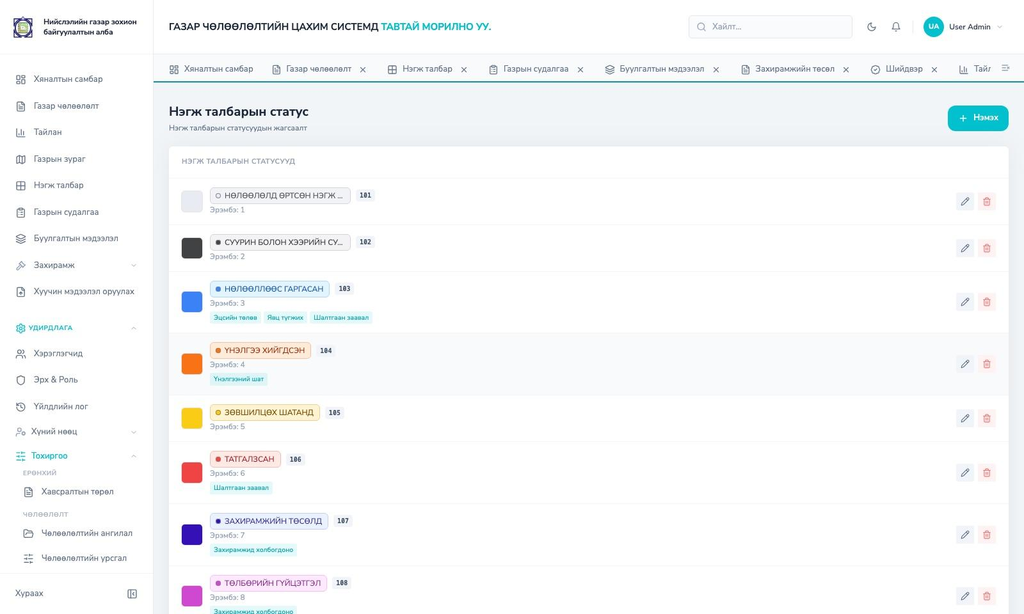

*Зураг 48. Нэгж талбарын статус: өнгө, эрэмбэ, дүрмийн тэмдэглэгээ*

### 9.12.5 Нэгж талбарын ажлын урсгал

**Цэс:** “Тохиргоо” цэсийн “Нэгж талбар”. **Зам:** `/parcel_workflow`

**Зорилго.** Нэгж талбарын төлөв хоорондын зөвшөөрөгдсөн шилжилт болон шилжилт бүрт заавал хавсаргах баримтын төрлийг тохируулна. Нэгж талбарын “Явц” табын “Явц нэмэх” цонхонд зөвхөн одоогийн төлөвөөс тохируулсан шилжилтүүд гарч, заавал хавсралт дутуу бол систем дутуу баримтын нэрийг зааж шилжилтийг зогсооно.

- **Харагдах мэдээлэл:** Эхлэх төлөвөөр бүлэглэсэн очих төлөвүүд (тохируулсан өнгөөр, эрэмбийн дугаартай). Шилжилт бүрийн доор заавал хавсралтын төрлүүд эсвэл “Заавал хавсралтгүй” гэж харагдана.
- **Үйлдлүүд**
  - “Шилжилт нэмэх” маягт: Эхлэх статус, Очих статус*, Заавал хавсралт (хавсралтын төрлүүдийн чагтлах жагсаалт), Эрэмбэ
  - “Заавал хавсралт засах” (харандаа) товчоор зөвхөн заавал хавсралтын жагсаалтыг засна.
  - Устгах үйлдэл “Шилжилтийг устгах уу?” баталгаажуулалттай бөгөөд заавал хавсралтын тохиргоо хамт устна.

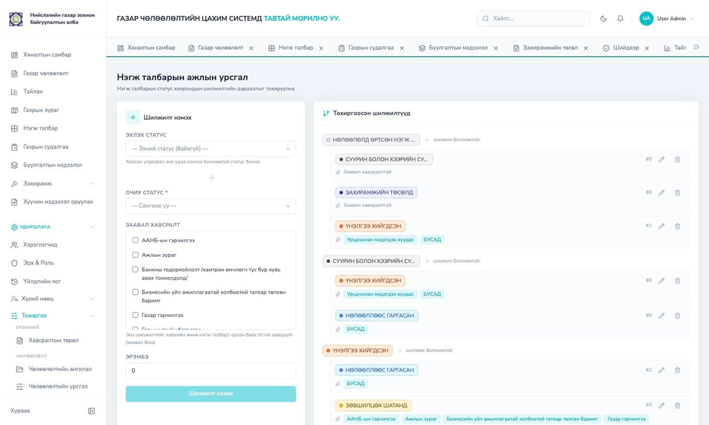

*Зураг 49. Нэгж талбарын ажлын урсгал: шилжилт ба заавал хавсаргах баримт*

### 9.12.6 Байгууламжийн чанарын төрөл

**Цэс:** “Тохиргоо” цэсийн “Үнэлгээ”. **Зам:** `/asset_spec_type`

**Зорилго.** Барилга байгууламжийн чанарын үзүүлэлтийн жагсаалтыг (хийцийн төрөл, суурь бүтэц, хана, хучилт-дээвэр, хаалга, цонх, халаалтын шийдэл, чанар) тохируулна. Төрөл бүр нэгж талбарын хөрөнгийн маягтын “Барилгын үзүүлэлт” хэсэгт тусдаа талбар болж гарах ба үнэлгээг Excel-ээс оруулахад нэрээрээ тулгагдана. Жишээ: шинэ төрөл нэмбэл бүх барилгын маягтад шинэ талбар нэмэгдэнэ.

- **Харагдах мэдээлэл:** Нэр, код, эрэмбэ (маягт дахь дарааллыг тодорхойлно).
- **Үйлдлүүд**
  - “Нэмэх” маягт: Код*, Нэр*, Эрэмбэ. Засах, устгах боломжтой (хөрөнгийн бүртгэлд утга нь хадгалагдсан төрлийг устгахгүй).

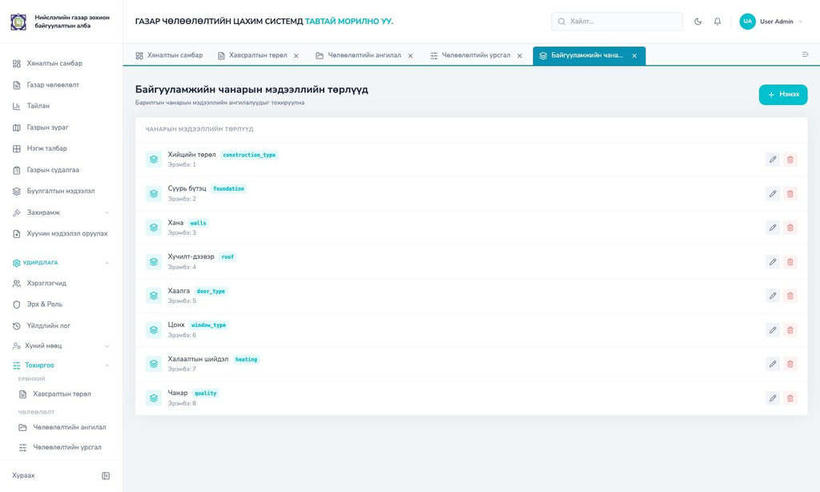

*Зураг 50. Байгууламжийн чанарын мэдээллийн төрлүүд*

### 9.12.7 Байгууламжийн тооцооллын төрөл

**Цэс:** “Тохиргоо” цэсийн “Үнэлгээ”. **Зам:** `/asset_calc_type`

**Зорилго.** Барилгын өртгийн хандлагаарх тооцооллын үзүүлэлтүүд (нэгжийн өртөг, итгэлцүүрүүд, бүрэн орлуулах өртөг, элэгдлийн хувь ба дүн, нөхөн орлуулах өртөг) болон хэмжих нэгжийг тохируулна. Төрөл бүр хөрөнгийн маягтын “Байгууламжийн өртгийн хандлагаарх тооцоолол” хүснэгтэд мөр болох ба систем элэгдэл, орлуулах өртгийг үндсэн төрлүүдийн кодоор автоматаар тооцно. Excel-ээс үнэлгээ оруулахад таарах төрөл олдоогүй мөрийг шинэ төрөл болгон нэмнэ.

- **Харагдах мэдээлэл:** Нэр, код, үндсэн хэмжих нэгж, эрэмбэ.
- **Үйлдлүүд**
  - “Нэмэх” маягт: Код*, Нэр*, Үндсэн хэмжих нэгж, Эрэмбэ. Засах, устгах боломжтой (тооцоололд ашиглагдсан төрлийг устгахгүй).

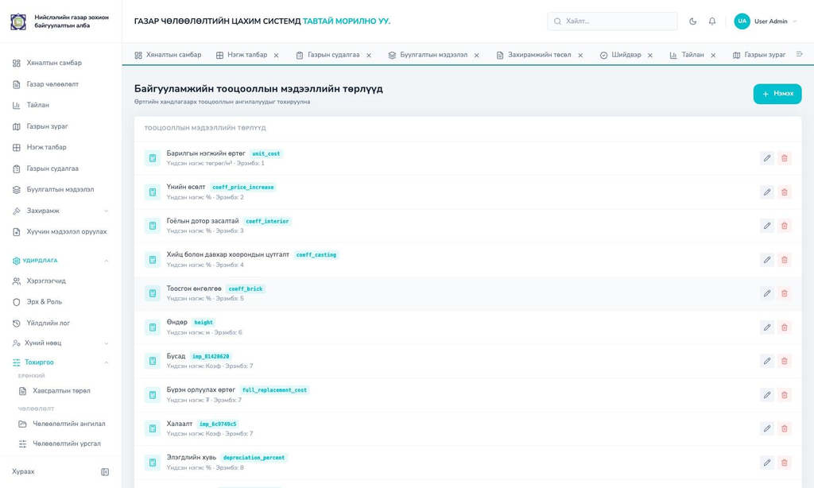

*Зураг 51. Байгууламжийн тооцооллын мэдээллийн төрлүүд*

### 9.12.8 Ажлын төрөл

**Цэс:** “Тохиргоо” цэсийн “Захирамжийн төсөл”. **Зам:** `/decision_work_type`

**Зорилго.** Захирамжийн төсөл үүсгэх, засах маягтын “Ажлын төрөл” заавал сонголтын лавлах бөгөөд захирамжийн жагсаалтын “Ажлын төрөл” баганад харагдана.

- **Харагдах мэдээлэл:** Нэр, код, эрэмбэ.
- **Үйлдлүүд**
  - “Нэмэх” маягт: Код* (жишээ: 10.2.1), Нэр*, Эрэмбэ. Засах, устгах боломжтой (захирамжийн төсөлд ашиглагдсан утгыг устгахгүй).

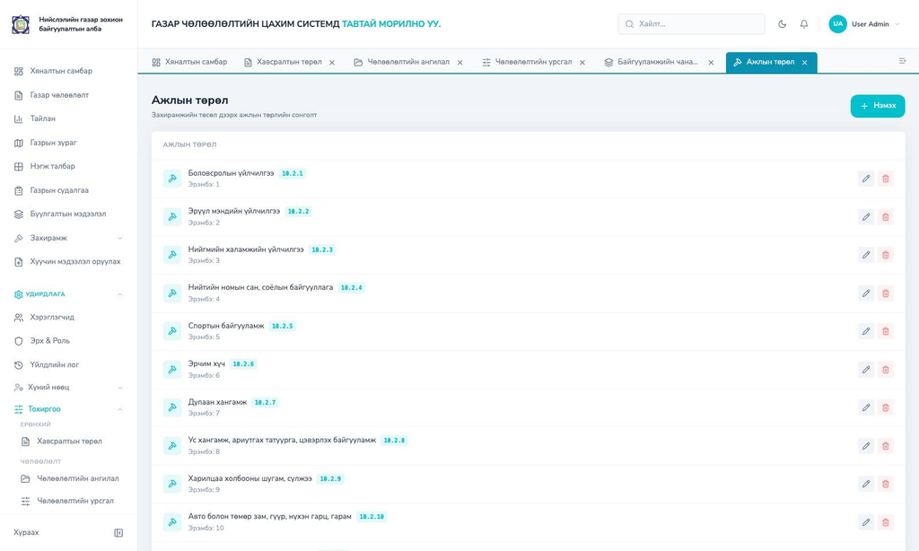

*Зураг 52. Захирамжийн ажлын төрөл*

### 9.12.9 Төсөв

**Цэс:** “Тохиргоо” цэсийн “Захирамжийн төсөл”. **Зам:** `/decision_budget`

**Зорилго.** Захирамжийн төслийн “Төсөв” заавал сонголтын лавлах бөгөөд жагсаалтын “Төсөв” баганад харагдана. Жишээ: шинэ төсвийн төрөл нэмбэл төсөл үүсгэх цонхонд сонгох боломжтой болно.

- **Харагдах мэдээлэл:** Нэр, код, эрэмбэ.
- **Үйлдлүүд**
  - “Нэмэх” маягт: Код* (жишээ: state_budget), Нэр*, Эрэмбэ. Засах, устгах боломжтой (ашиглагдсан утгыг устгахгүй).

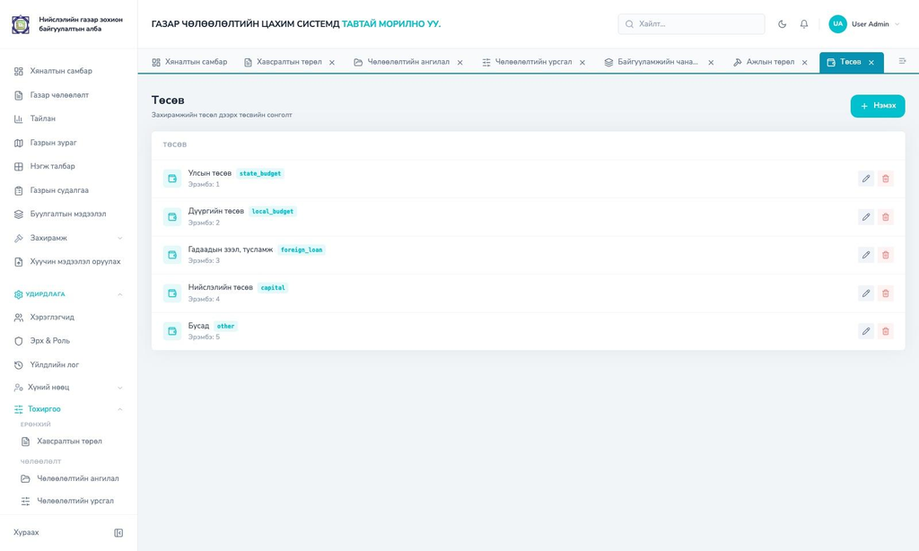

*Зураг 53. Захирамжийн төсөв*

### 9.12.10 Төсөл хянах нэгж

**Цэс:** “Тохиргоо” цэсийн “Захирамжийн төсөл”. **Зам:** `/decision_review_unit`

**Зорилго.** Захирамжийн төслийн “Явц нэмэх” цонхонд “Хянагдаж буй” төрөл сонгоход гарах “Хянагдаж буй газар” сонголтын лавлах. Лавлах хоосон бол цонхонд энд нэмэхийг сануулна. Жишээ: хуулийн хэлтсийг нэмбэл төслийг тэнд хянагдаж буй гэж тэмдэглэх боломжтой болно.

- **Харагдах мэдээлэл:** Нэр, код, эрэмбэ.
- **Үйлдлүүд**
  - “Нэмэх” маягт: Код* (жишээ: legal_department), Нэр*, Эрэмбэ. Засах, устгах боломжтой (захирамжийн явцад ашиглагдсан утгыг устгахгүй).

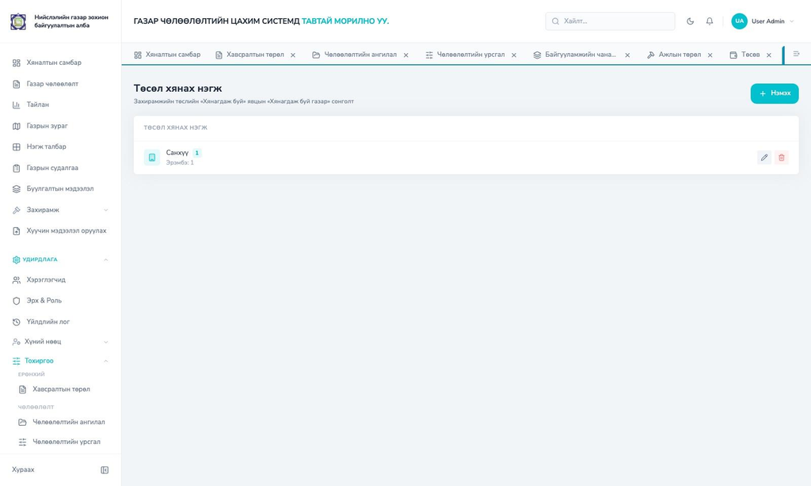

*Зураг 54. Төсөл хянах нэгж*

### 9.12.11 Хүний нөөцийн 6 бүртгэл

**Цэс:** “Удирдлага” цэсийн “Хүний нөөц”. **Эрх:** “Админ” роль ба `hr:read|create|update|delete`

Байгууллага, ажилтан, иргэн, үнэлгээний байгууллагын суурь бүртгэлүүд. Жагсаалтууд баганаар эрэмбэлэгдэж, “Нийт N бүртгэл” гэж харагдана. Ажилтан, иргэний бүртгэлийг бүрмөсөн устгахын оронд идэвхгүй болгох зарчмаар ажилладаг тул түүхэн бичлэгүүд эзэнгүй болохгүй.

| **Бүртгэл** | **Зорилго** | **Харагдах мэдээлэл** | **Үйлдлүүд** | **Шүүлтүүр** |
| --- | --- | --- | --- | --- |
| **Иргэн, хуулийн этгээд** `/person` | Иргэн ба хуулийн этгээдийн суурь бүртгэл. Ажилтан, эрх эзэмшигч зэрэг бүртгэл үүнтэй холбогдоно. | Нэр, төрөл, регистр/ТТД, утас, имэйл | “Нэмэх” маягт: Төрөл, Регистр/ТТД*, Овог*, Нэр* (хуулийн этгээд бол нэр*). Засах боломжтой, хүний бүртгэлийг устгахгүй. | Регистр, нэрээр хайх |
| **Ажилтан** `/employee` | Ажилтныг иргэний бүртгэлтэй холбож байгууллага, алба хэлтэс, албан тушаалд бүртгэнэ. Алба хэлтэс нь ажилтны харах мэдээллийн хүрээг тодорхойлно. | Ажилтан, албан тушаал, алба хэлтэс, байгууллага, ажлын имэйл (зөвхөн идэвхтэй) | “Нэмэх” маягт: Байгууллага*, Алба хэлтэс, Албан тушаал*, ажлын имэйл, утас, иргэн сонгох эсвэл “Шинэ иргэн бүртгэх”. Засах боломжтой, устгахын оронд идэвхгүй болгоно (нэвтрэх эрх хамт хаагдана). | Нэр, регистр, имэйлээр хайх |
| **Байгууллага** `/organization` | Байгууллагын лавлах. Алба хэлтэс, ажилтан үүнд харьяалагдана. | Нэр | “Нэмэх” маягт: Нэр*. Засах боломжтой, алба хэлтэстэй байгууллагыг устгахгүй. | Нэрээр хайх |
| **Үнэлгээний байгууллага** `/valuation_org` | Хөрөнгийн үнэлгээ хийх мэргэжлийн байгууллага ба түүний ажилтнууд. Нэвтрэх нэр өгсөн ажилтан зөвхөн өөрийн байгууллагад оноогдсон ажил дээр ажиллана. | Нэр, ТТД, тусгай зөвшөөрөл, хүчинтэй хугацаа, ажилтны тоо, төлөв | “Шинэ байгууллага” маягтад байгууллагын мэдээлэл ба ажилтнуудыг (нэвтрэх нэр, нууц үгтэй) оруулна. “Идэвхтэй эсэх” чагтыг авбал бүх ажилтны нэвтрэх эрх хаагдана. Оноогдсон байгууллагыг устгахгүй. | Нэр, ТТД, тусгай зөвшөөрлөөр хайх |
| **Алба, хэлтэс** `/department` | Байгууллагын бүтцийн нэгж. Чөлөөлөлтийн ангиллын “Хариуцсан алба” эндээс сонгогдож, мэдээлэл харах хүрээг тодорхойлно. | Нэр, код, байгууллага | “Нэмэх” маягт: Байгууллага*, Нэр*, Код. Засах боломжтой, идэвхтэй ажилтантай албыг устгахгүй. | Нэр, кодоор хайх, байгууллагаар шүүх |
| **Албан тушаал** `/position` | Албан тушаалын лавлах. Ажилтан бүртгэхэд заавал сонгогдоно. | Нэр, код | “Нэмэх” маягт: Нэр*, Код. Засах боломжтой, ажилтанд оноогдсон албан тушаалыг устгахгүй. | Нэр, кодоор хайх |

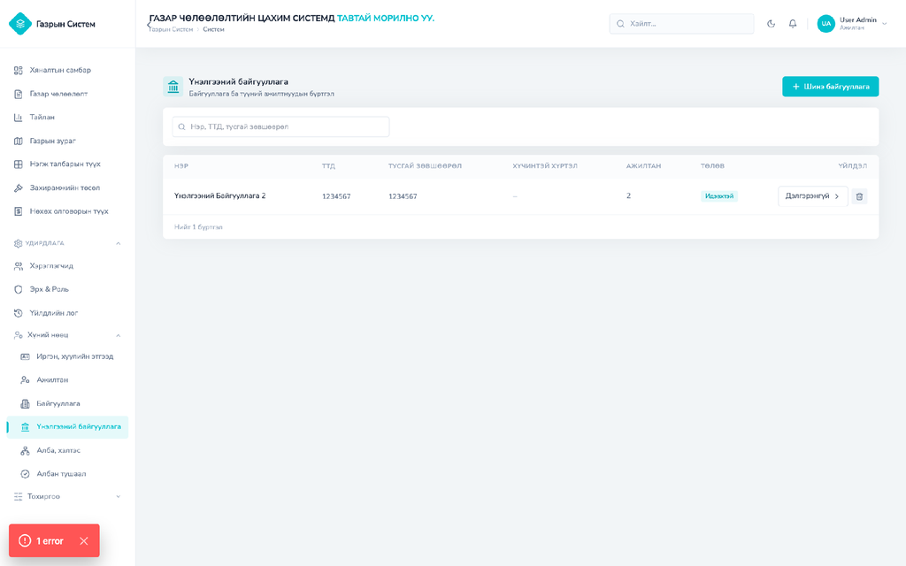

*Зураг 55. Үнэлгээний байгууллагын бүртгэл: тусгай зөвшөөрөл, хүчинтэй хугацаа, ажилтны тоо, төлөв*

### 9.13 Бодит цагийн мэдэгдлийн систем

**Технологи:** Server-Sent Events. **Endpoint:** 5

**Зорилго.** Ажлын төлөв өөрчлөгдөх бүрт холбогдох хэрэглэгчдэд шууд мэдэгдэж, хариу үйлдэл хийх хугацааг богиносгох.

Мэдээллийн төлөв өөрчлөгдөх бүрт тухайн мэдээлэлтэй холбоотой бүх хэрэглэгчид мэдэгдэл үүсэж, Server-Sent Events (SSE) стриймээр хөтөч рүү шууд түгээгдэнэ. Мэдэгдэл дээр дарахад холбогдох мэдээллийн дэлгэрэнгүй хуудас руу шилжинэ.

- **Архитектур:** Мэдэгдэл notification хүснэгт (main DB), NotificationService, in-memory SSE hub, хөтчийн стрийм гэсэн дарааллаар дамжина. Мэдэгдэл эхлээд DB-д хадгалагдаж, дараа нь идэвхтэй холболтууд руу түгээгдэх тул холболт тасарсан үед ч мэдээлэл алдагдахгүй.

| **Endpoint** | **Үүрэг** |
| --- | --- |
| **GET /notifications** | Өөрийн мэдэгдлийн жагсаалт (хуудаслалт, unread шүүлт) |
| **GET /notifications/unread-count** | Уншаагүй мэдэгдлийн тоо |
| **GET /notifications/stream** | SSE бодит цагийн стрийм (25с heartbeat-тэй) |
| **POST /notifications/{id}/read** | Нэг мэдэгдлийг уншсан болгох |
| **POST /notifications/read-all** | Бүгдийг уншсан болгох |

**Мэдэгдэл илгээгдэх үйл явдлууд ба хүлээн авагчид:**

| **Үйл явдал** | **Хүлээн авагчид** |
| --- | --- |
| **Чөлөөлөлтийн статус шилжилт** | Хуваарилагдсан ажилтнууд + мэргэжлийн байгууллага |
| **Талбарын статус шилжилт** | Хуваарилагдсан ажилтнууд |
| **Талбар “Үнэлгээ хийх” төлөвт орох** | Мэргэжлийн байгууллага болон сонгогдсон хөндлөнгийн байгууллага (тусгай “Үнэлгээ хийх талбар ирлээ” мэдэгдэл) |
| **Үнэлгээ илгээх (submit)** | Санхүүгийн мэргэжилтнүүд + ажилтнууд |
| **Үнэлгээ батлах / буцаах** | Илгээсэн этгээд + байгууллагууд + ажилтнууд |
| **Олговор бүртгэх** | Санхүүгийн мэргэжилтнүүд + ажилтнууд |
| **Олговор батлах / татгалзах** | Бүртгэсэн этгээд + ажилтнууд + мэрг. байгууллага |
| **Ажилтан хуваарилах** | Зөвхөн шинээр нэмэгдсэн ажилтнууд |
| **Байгууллага оноох** | Тухайн байгууллага |

- **Дүрэм:** Үйлдэл хийсэн хүн өөрөө өөрийн үйлдлийн мэдэгдлийг авахгүй, давхардсан хүлээн авагч нэг л мэдэгдэл авна.
- **Хэрэглэгчийн интерфейс:** Толгой цэсийн хонх нь уншаагүйн badge-тэй бөгөөд шинэ мэдэгдэлд “Харах” товчтой toast гарна. Дарахад уншсан болж, дэлгэрэнгүй рүү шилжинэ. Таб идэвхжих эсвэл сүлжээ сэргэхэд стрийм автоматаар дахин холбогдож, тасалдлын үеийн мэдэгдлүүдийг нөхөж татна.

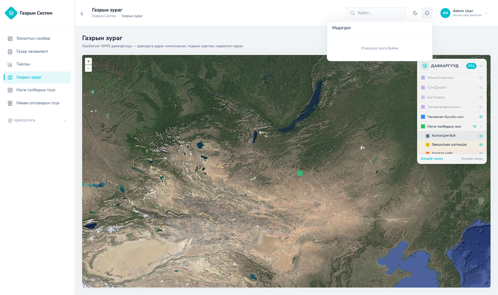

- **Аюулгүй байдал, найдвартай байдал:** Token нь Authorization header-ээр дамждаг тул URL-д гардаггүй бөгөөд лог/түүхэд нууц үлдэхгүй. Хэрэглэгч зөвхөн өөрийн мэдэгдэлд ханддаг (repo түвшний recipient шүүлт). Нэг хэрэглэгчид дээд тал нь 8 зэрэгцээ стрийм зөвшөөрнө. Мэдэгдлийн алдаа үндсэн үйлдлийг хэзээ ч унагаахгүй (async).

### 9.14 Аудит лог буюу үйлдлийн мөрдлөг

**Зам:** `/audit_logs`. **Эрх:** `audit:read`

**Зорилго.** Системд хийгдсэн өөрчлөлт бүрийг хэн, хэзээ, хаанаас, юу өөрчилснөөр бүртгэж, хяналт шалгалтын эх сурвалж болгох.

Хэн, хэзээ, ямар төхөөрөмж/хаягаас, ямар объект дээр, ямар өөрчлөлт хийснийг бүртгэх audit_log хүснэгт (шүүлтийн индексүүдтэй, одоо нэгтгэсэн baseline migration-д багтсан) нэмэгдсэн.

| **Багана** | **Агуулга** |
| --- | --- |
| **actor_id, actor_name, actor_position, actor_roles** | Үйлдэл хийсэн хэрэглэгч (JWT-ээс автоматаар) |
| **action** | Үйлдлийн төрөл: created / updated / deleted / status_changed / valuation_submit / valuation_approve / valuation_return / imported / upserted г.м. |
| **resource_type, resource_id** | 8 төрлийн объект: acquisition, parcel, valuation, compensation, document, payment, funding_source, authorized_representative |
| **acquisition_id, parcel_id** | Холбогдох чөлөөлөлт/талбар (хайлтад ашиглагдана) |
| **details (JSONB)** | Үйлдлийн дэлгэрэнгүй: өөрчилсөн утгууд, тоо хэмжээ (жишээ нь импортын үед үүссэн/устсан мөрийн тоо) |
| **ip_address, user_agent** | Хүсэлт ирсэн IP хаяг, хөтчийн мэдээлэл |
| **created_at** | Үйлдлийн огноо, цаг |

- **Бүртгэх цэгүүд:** Land service-ийн 36 мутацийн цэгээс бүртгэгдэнэ. Үүнд статус шилжилт, үнэлгээний илгээх/батлах/буцаах, олговор үүсгэх/засах/устгах/батлах, Excel импорт, санхүүжилт, төлөөлөгч зэрэг орно.
- **Автомат actor:** Actor-ийн мэдээлэл (нэр, албан тушаал, роль, IP, User-Agent) auth middleware-ээс request context-оор автоматаар дамждаг тул handler бүрт код нэмэх шаардлагагүй.
- **Гүйцэтгэл:** Async fire-and-forget горимоор ажилладаг тул лог бичилт үндсэн үйлдлийг удаашруулахгүй, алдаа гарвал зөвхөн серверийн логт тэмдэглэгдэнэ.
- **Хандалт:** GET /audit-logs endpoint-д audit:read зөвшөөрөлтэй (одоогоор зөвхөн админ) хэрэглэгч хандаж, actor, action, resource, огнооны мужаар шүүж хуудаслан харна. Frontend-д “Аудит лог” жагсаалтын дэлгэц (/audit_logs) нэмэгдсэн.
- **Гадаад системийн дуудлагын лог:** Ижил зарчмаар backend-ээс бусад (гадаад) систем рүү илгээсэн HTTP дуудлага бүрийг бүртгэдэг `client_request` хүснэгт, `GET /client-requests` endpoint нэмэгдсэн (5-р бүлэгт дэлгэрэнгүй).

[output not shown]

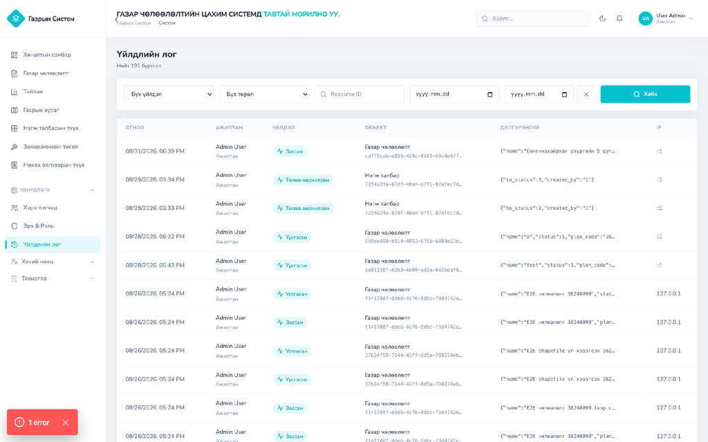

*Зураг 57. Үйлдлийн лог: үйлдэл, объектын төрөл, огноогоор шүүх, дэлгэрэнгүй JSON*

### 9.15 Цэс ба ажиллах дараалал

Цэс бүр эрхээр шүүгдэж, эрхгүй хэсэг огт харагдахгүй

Энэ хэсэгт системийн цэсийн бүтэц, роль тус бүрийн харагдац, гол ажиллах урсгалуудын (чөлөөлөлт, нэгж талбар, үнэлгээ) төлөвийн шилжилтийн дараалал болон код дотор бодитоор мөрдөгдөж буй шаардлагын (requirement) дүрмүүдийг нэгтгэв.

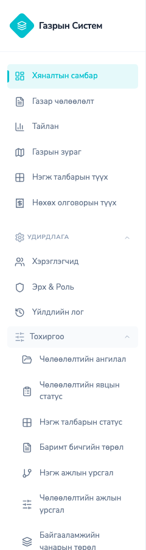

*Зураг 58. Цэсийн бүтэц: Удирдлага, Тохиргоо дэд цэсүүд дэлгэрсэн байдалтай*

**9.15.1 Цэсийн бүтэц, роль тус бүрийн харагдац**

| **Цэс** | **Зам** | **Харагдах роль** |
| --- | --- | --- |
| Хяналтын самбар | / | Бүх роль (гадаад ролиудад хураангуй хувилбар, санхүүгийн мэргэжилтэнд санхүүгийн самбар) |
| Газар чөлөөлөлт | /acquisition | Дотоод роль (бүрэн). МИКА, Санхүү (зөвхөн энэ + самбар + нэгж талбар) |
| Тайлан | /report | Ахлах мэргэжилтэн, администратор |
| Газрын зураг | /map | Дотоод роль |
| Нэгж талбар | /parcel | Дотоод роль, санхүүгийн мэргэжилтэн |
| Газрын судалгаа | /parcel_survey | `land:read` зөвшөөрөлтэй дотоод хэрэглэгч |
| Буулгалтын мэдээлэл | /land_release | `land:read` зөвшөөрөлтэй дотоод хэрэглэгч |
| Захирамж (дэд цэс) |  |  |
| Захирамжийн төсөл | /decision_draft | `decision:read` зөвшөөрөлтэй дотоод хэрэглэгч |
| Шийдвэр | /decision | `decision:read` зөвшөөрөлтэй дотоод хэрэглэгч |
| Хуучин мэдээлэл оруулах | /legacy_import | Зөвхөн системийн администратор |
| Миний чөлөөлөлтүүд | /my_acquisitions | Зөвхөн мэргэжлийн байгууллага (өөрийн тусдаа хураангуй цэс) |
| Удирдлага (дэд цэс) |  |  |
| Хэрэглэгчид | /users | Администратор, `users:read` |
| Эрх & Роль | /roles | `roles:read` |
| Үйлдлийн лог | /audit_logs | `audit:read` (одоогоор зөвхөн администратор) |
| Хүний нөөц (6 бүртгэл) | /person, /employee, /organization, /valuation_org, /department, /position | Администратор, `hr:read` |
| Тохиргоо (дэд цэс, 10 модуль, 5 бүлэг) |  |  |
| Ерөнхий | /document_type | Администратор эсвэл `admin:*` зөвшөөрөл |
| Чөлөөлөлт | /acquisition_category, /acquisition_workflow | Мөн адил |
| Нэгж талбар | /parcel_status, /parcel_workflow | Мөн адил |
| Үнэлгээ | /asset_spec_type, /asset_calc_type | Мөн адил |
| Захирамжийн төсөл | /decision_work_type, /decision_budget, /decision_review_unit | Мөн адил |

*2026-10-21-нд “Нөхөх олговрын түүх” ба “Чөлөөлөлтийн явцын статус” цэс хасагдсан. Хажуугийн цэс хураасан төлөвөө санах ба нээсэн хуудас бүр хөтчийн таб шиг дээд мөрөнд хадгалагдаж, хооронд нь шилжихэд хуудас дахин ачаалагдахгүй.*

**9.15.2 Газар чөлөөлөлтийн ажиллах дараалал**

**1. Шинэ:** Төлөвлөгөөнөөс бүртгэгдсэн шинэ чөлөөлөлт

↓

**2. Хээрийн судалгаа:** Нэгж талбарууд бүртгэгдэж, судалгаа хийгдэж буй үе шат

↓

**3. Баталгаажсан:** Эцсийн, буцаах боломжгүй төлөв бөгөөд бүх засвар түгждэг

*Аль ч үе шатанд “Цуцлагдсан” (4) төлөвт шилжих боломжтой (тохиргооноос хамаарна).*

**“Баталгаажсан” руу шилжих 2 заавал нөхцөл** (AdvanceStatus функцээр код дотор шалгагддаг): (1) НЗД-ын захирамжийн дугаар болон огноо заавал бөглөгдсөн байх ёстой, үгүй бол “Захирамжийн мэдээлэл дутуу байна” алдаа буцна. (2) Чөлөөлөлт дэх **бүх** нэгж талбар эцсийн гурван төлөвийн (Нөлөөлөгдсөн гарсан, Татгалзсан, Чөлөөлсөн) аль нэгэнд байх ёстой, эс бөгөөс “Бүх нэгж талбар эцсийн төлөвт байх шаардлагатай” алдаа буцна. Хэрэв тохиргооны `acquisition_workflow` хүснэгтэд шилжилтийн дүрэм нэмээгүй бол систем зөвхөн “дараагийн дугаар руу л” шилжихийг зөвшөөрдөг (буцах боломжгүй).

**9.15.3 Нэгж талбарын ажиллах дараалал**

**101. Нөлөөлөлд өртсөн нэгж талбар:** Чөлөөлөх хилээр тодорхойлогдож бүртгэгдсэн

↓

**102. Суурин болон хээрийн судалгаа:** Мэдээлэл татах, эзэмшигчтэй уулзах, судалгаа хийх

↓

↓

**105. Зөвшилцөх шатанд:** Эзэмшигчтэй нөхөх олговрыг зөвшилцөх

↓

**107. Захирамжийн төсөлд:** Нөхөх олговор батлагдаж, захирамжийн төсөлд холбогдоно

↓

**108. Төлбөрийн гүйцэтгэл:** Нөхөх олговрыг 60%, 40% эсвэл бүтнээр олгох

↓

**109. Чөлөөлсөн:** Эцсийн төлөв, газрыг хүлээлцэн чөлөөлсөн

Аль ч шатнаас **“Нөлөөллөөс гаргасан” (103)** эсвэл **“Татгалзсан” (106)** төлөвт шилжүүлж болох ба эдгээрт шалтгаан заавал бичнэ. Төлөвийн нэр, өнгө, дараалал, түгжээ, эцсийн төлөв зэрэг дүрмийг “Нэгж талбарын статус” (9.12.4), аль төлөвөөс аль төлөв рүү шилжих ба шилжилт бүрт заавал хавсаргах баримтыг “Нэгж талбарын ажлын урсгал” (9.12.5) тохиргооноос удирдана. **“Захирамжийн төсөлд” шилжих нөхцөл:** тухайн нэгж талбарын сонгосон үнэлгээний урсгалын (үндсэн/хөндлөнгийн/МИКА) нөхөх олговор баталгаажсан, үнэлгээний тайлан хавсаргагдсан байх ёстой. Эс бөгөөс систем шилжилтийг зогсоож, дутуу зүйлийг мэдэгдэнэ.

**9.15.4 Үнэлгээ илгээх дэд урсгал**

**Ноорог:** Засварлаж болно

↓

**Илгээсэн:** Санхүүгийн мэргэжилтний шийдвэрийг хүлээж буй

↓

**Баталгаажсан** эсвэл “Буцаагдсан”. Буцаагдсан бол ноорог руу буцаж, дахин засварлаж илгээх боломжтой.

“Илгээх” үйлдэл зөвхөн Ноорог/Буцаагдсан төлөвөөс, “Батлах”/“Буцаах” үйлдэл зөвхөн Илгээсэн төлөвөөс хийгдэнэ (өөр төлөвөөс оролдвол “Хүчингүй шилжилт” алдаа буцна). **Илгээхийн өмнөх нөхцөл:** “Үл хөдлөх” төрлийн хөрөнгө бүрт зураг (PDF) хавсаргасан байх ёстой, үгүй бол “Үл хөдлөх хөрөнгө бүрт зураг хавсаргасны дараа илгээх боломжтой” алдаа буцна. Батлагдсан урсгал автоматаар тухайн талбарын үндсэн (`selected_valuation_type`) урсгал болж, бусад 2 урсгал “Идэвхгүй” болдог.

**9.15.5 Бусад объект түвшний хамгаалалт ба шаардлагын дүрэм**

[output not shown]

### 9.16 Хяналт, лог ба Grafana

**Нэмэлт ажил** (10.3-ыг үзнэ үү)

**Зорилго.** Системийн бүх бүрэлдэхүүний лог, алдааг нэг дор цуглуулж, хэвийн ажиллагааг хянах.

Систем 2026.07-с эхлэн Frontend, Backend хоёулаа нэг нэгдсэн лог/хяналтын урсгалд холбогдсон. Доор энэ урсгал яг хэрхэн ажилладгийг эх сурвалжаас нь дэлгэрэнгүй тайлбарлав.

**1. Үүсэх (Frontend):** Хөтчийн алдаа (error.tsx, global-error.tsx) болон бусад лог /api/client-log route-оор дамжиж, Next.js серверийн stdout руу JSON мөр болж бичигдэнэ

↓

**1. Үүсэх (Backend):** Gin middleware болон бизнес логик slog-оор JSON бүтэцтэй лог (method, зам, статус, хугацаа, IP) серверийн stdout руу шууд бичигдэнэ

↓

**2. Хуримтлуулах (Docker):** Frontend, Backend, PostgreSQL гэсэн 3 контейнерийн stdout Docker-ийн json-file драйверт (10MB × 3 файл rotation) хадгалагдана

↓

**3. Цуглуулах (Promtail):** Docker socket-оор бүх контейнерийг автоматаар илрүүлж (шинэ сервис нэмэгдэхэд тохиргоо засах шаардлагагүй), container_name/service/project шошготойгоор Loki руу дамжуулна

↓

**4. Хадгалах (Loki):** Порт 3100, файлын системд хадгалж, 30 хоногийн (720 цаг) хугацаагаар хадгална, хугацаа дууссаныг автоматаар устгадаг

↓

**5. Харах (Grafana):** Гадна порт 3001 нь дотор порт 3000 руу холбогдоно, Loki datasource-той урьдчилан холбогдсон, “Logs Drilldown” өргөтгөлтэй

- Backend API процесс ажиллаж эхлэхэд `gov_loki`, `gov_promtail`, `gov_grafana` 3 контейнер ажиллаж байгаа эсэхийг шалгаж, байхгүй бол өөрөө `docker compose up -d` ажиллуулна
- Docker байхгүй эсвэл эхлэхэд алдаа гарвал зөвхөн анхааруулга бичиж, үндсэн API-г унагаахгүй (best-effort)
- Grafana анонимаар нэвтрэхийг хориглосон, админ хэрэглэгч/нууц үг орчны хувьсагчаар тохируулагдана
- Нууц (нууц үг, token) утгууд лог руу бичигдэхээс өмнө хөтөч болон серверийн 2 талд аль алинд нь хасагдана (redaction)

[figure not shown]

*Зураг 59. Grafana: нэвтэрсэн байдал, хяналтын самбарын нүүр хуудас*

Энэ бүтэц нь **төлөвлөгөөнд тусгайлан заагаагүй** байсан ч хөгжүүлэлтийн явцад алдааг хурдан илрүүлэх, мөрдөх шаардлагаас үүдэн нэмэгдсэн тул тайлангийн 10.3-т “Нэмэлт ажлууд”-ын нэг хэсэг болгон тооцов.

### 9.17 Газрын судалгаа

**Зам:** `/parcel_survey` (мөн нэгж талбарын “Судалгаа”, чөлөөлөлтийн “Газрын судалгаа” таб). **Хандах:** `land:read` зөвшөөрөлтэй дотоод хэрэглэгч, бөглөх нь `land:update`.

**Зорилго.** Чөлөөлөгдсөн газрын нийгмийн нөхцөл байдлын мэдээллийг нэгж талбар бүрээр цуглуулж нэгтгэх. Нэгж талбар системд бүртгэгдэх үед судалгааны хоосон бүртгэл автоматаар үүсдэг тул бөглөөгүй судалгаа жагсаалтад шууд харагдана.

- **Харагдах мэдээлэл:** дээд хэсгийн хураангуй картууд нь “Яндангийн тоо”, “Нойлын тоо”, “Хажуу өрхийн судалгаа”, “Шилжин суурьшсан байршил” (гэр хороолол, орон сууц: тоо ба хувь). Жагсаалтын баганууд нь нэгж талбар, чөлөөлөлт, яндангийн тоо, нойлын тоо, хажуу өрхийн судалгаа, шилжин суурьшсан байршил, шинэчилсэн огноо, бөглөсөн эсэх.
- **Шүүлтүүр:** чөлөөлөлтийн нэр, нэгж талбарын дугаар, бөглөсөн эсэхээр шүүнэ, мөн баганаар эрэмбэлнэ.
- **Үйлдлүүд:** мөр бүрийн “Бөглөх” товчоор нэгж талбарын “Судалгаа” таб нээгдэж, яндан, нойлын тоо (+/− товчоор), хажуу өрхийн судалгаа, шилжин суурьшсан байршил, тайлбарыг бөглөөд “Хадгалах” товч дарна.
- **Уялдаа:** чөлөөлөлтийн “Газрын судалгаа” таб ба хяналтын самбарын бүтэн дэлгэцийн хураангуйд тухайн чөлөөлөлтийн судалгааны нэгтгэл харагдана.

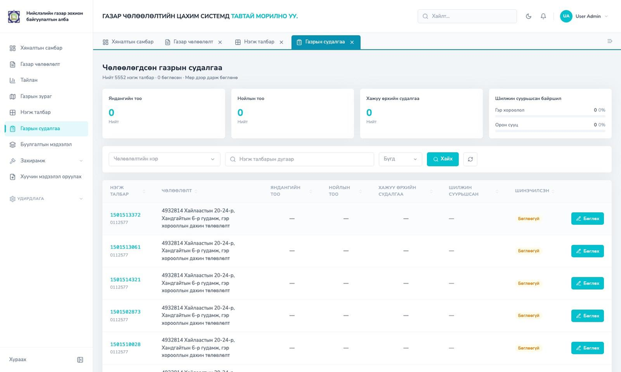

*Зураг 60. Газрын судалгаа: хураангуй картууд, шүүлтүүр, нэгж талбар тус бүрийн судалгаа*

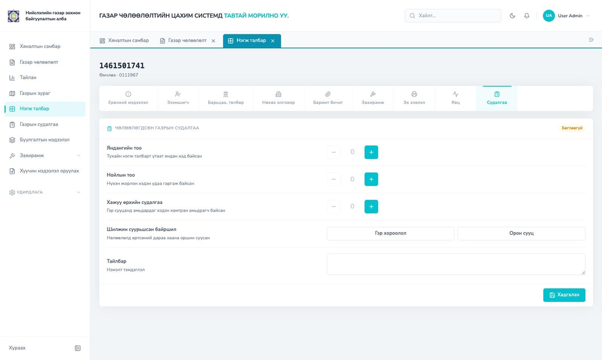

*Зураг 61. Нэгж талбарын “Судалгаа” таб: судалгаа бөглөх маягт*

### 9.18 Буулгалтын мэдээлэл

**Зам:** `/land_release`, `/land_release/[id]`. **Хандах:** `land:read` зөвшөөрөлтэй дотоод хэрэглэгч (гадаад ролиудад харагдахгүй), харин оруулах, төлөв солих нь бичих эрхтэй хэрэглэгчид.

**Зорилго.** Буулгах шаардлагатай барилга байгууламжтай газрыг нэгж талбарын үндсэн бүртгэлээс тусад нь бүртгэж, захирамж гарч чөлөөлөгдөх хүртэлх явцыг хянах бие даасан модуль.

- **Оруулах:** олон газрыг shapefile-аар нэг дор оруулна, оруулахын өмнө урьдчилан харж шалгана. Газар бүрт нэр, байгууламжийн төрөл (жагсаалтаас сонгох эсвэл шинээр нэмэх), зураг (олон зураг нэг PDF болж нэгтгэгдэнэ), захирамжийн дугаар ба PDF хавсаргана.
- **Төлөв:** “Төлөвлөж байгаа” төлөвөөс “Захирамж гарч чөлөөлсөн” эсвэл “Хүчингүй” төлөв рүү шилжинэ. Төлөв солих бүр түүхэд бүртгэгдэнэ.
- **Шүүлтүүр:** буулгалтын нэр, захирамжийн дугаар эсвэл Б-дугаараар хайх, мөн төлөв, дүүрэг/сум, байгууламжийн төрөл, оноор шүүх
- **Харагдах мэдээлэл:** байршлын газрын зураг (төлөвийн өнгөөр, бөөгнөрлийн тоотой). Нийт газар, нийт талбай, захирамжийн тоо, төлөв тус бүрийн тоо ба талбай. Аймаг/хот, сум/дүүрэг тус бүрийн газар, чөлөөлсөн тоо, талбай. Мөн газар ба захирамжийн тоог оноор харуулсан график.
- **Дэлгэрэнгүй:** газрын хил бүхий зураг, ерөнхий мэдээлэл (нэр, байгууламжийн төрөл, талбай, байршил, огноо), захирамж ба хавсралт, зургууд, төлөвийн түүх, мөн төлөв солих үйлдэл

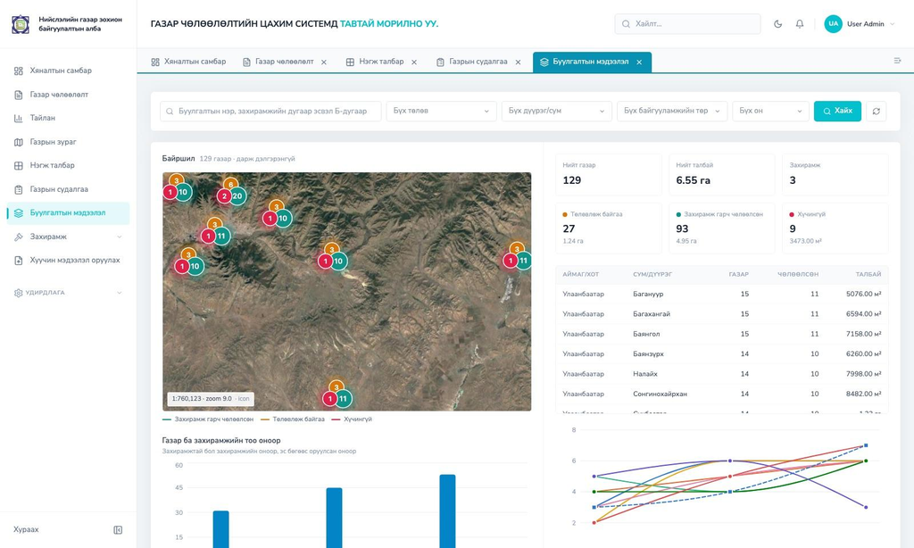

*Зураг 62. Буулгалтын мэдээлэл: газрын зураг, статистик, дүүрэг тус бүрийн задаргаа, оны график*

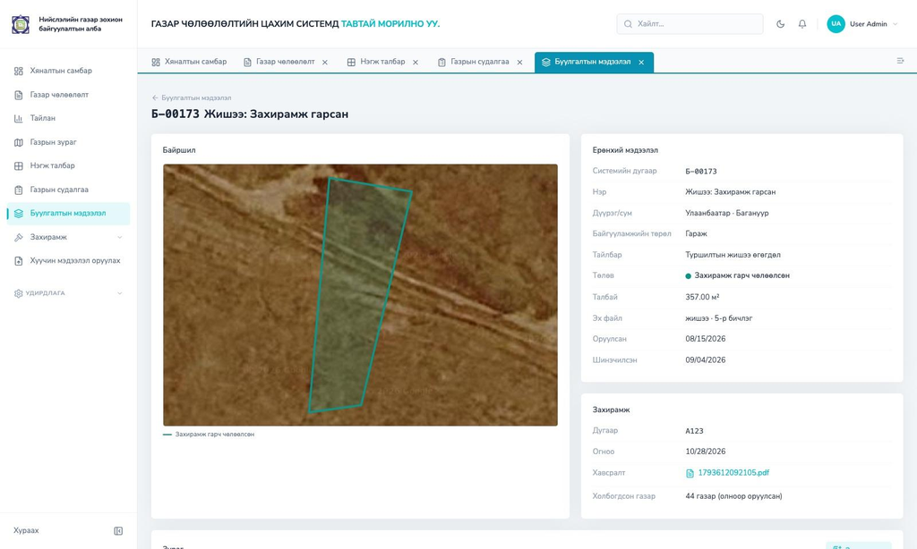

*Зураг 63. Буулгалтын дэлгэрэнгүй: хил, ерөнхий мэдээлэл, захирамж*

### 9.19 Хуучин мэдээлэл оруулах (2.7.1)

**Зам:** `/legacy_import`. **Хандах:** зөвхөн системийн администратор. **Файлын хязгаар:** 50MB (хавсралт 100MB).

**Зорилго.** 2010-2025 онд нөхөх олговортойгоор чөлөөлөгдсөн газрын мэдээллийг (чөлөөлөлт, нэгж талбар, нөхөх олговор, баримт) системд нөхөж оруулах. Файлуудыг эхлээд шалгаж түр хадгалах ба “Оруулах” дарсны дараа л системд бүртгэгдэнэ.

- **Жагсаалт:** өмнөх импортуудын огноо, оруулсан хэрэглэгч, горим, чөлөөлөлт, нэгж талбарын тоо, төлөв харагдана. Хайлт, хуудаслалт, “Дэлгэрэнгүй”, “Устгах” үйлдэлтэй.
- **“Шинэ импорт” (бүрэн горим, 4 алхам):** (1) **Чөлөөлөлтийн хил**: ерөнхий/дэд ангилал сонгож .shp файлыг оруулна, төлөвлөгөөтэй давхцлыг шалгана. (2) **Нэгж талбар**: .shp файлын нэгж талбаруудыг ГУС-тэй тулгаж хилээс гадуурх, давхардсан, санд аль хэдийн байгаа, дугааргүй нэгж талбарыг ялгаж харуулна. (3) **Үнэлгээ**: нөхөх олговрын Excel тайланг уншиж талбай, өмчлөгчийн зөрүүг анхааруулна. (4) **Нэгтгэл ба оруулах**: бүх алхмын дүнг харуулж, чөлөөлөлт, нэгж талбар, явцын түүх, нөхөх олговрыг нэг дор оруулна, мөн олговрын олголтын шатыг (60%, 40%, бүтэн) тооцно.
- **“Зөвхөн үнэлгээ” горим:** хил байхгүй архивын мэдээллийг Excel файлаас оруулж, чөлөөлөлтийг автоматаар үүсгэнэ. Чөлөөлөлт бүрт ангилал, НИТХ-ын тогтоол, хугацаа, хэрэгжүүлэгчийг гараар нэмнэ.
- **“Хавсралт оруулах”:** хавтсан дахь PDF файлуудыг нэрээр нь (файлын нэр нь нэгж талбарын дугаар) тааруулж “Нөхөх олговор олгосон баримт” болгон хавсаргана. Түгжигдсэн чөлөөлөлтөд ч хавсаргана.
- **Буцаах:** алдаатай импортыг “Устгах” товчоор бүхэлд нь буцаана. Юу устах, юу үлдэхийг урьдчилан харуулна.
- **Мэдээлэл нөхөх:** ГУС-т олдоогүй нэгж талбарыг хуучин дугаараар болон Улаанбаатар хотын нэгж талбарын сангаас нөхөж хайна.

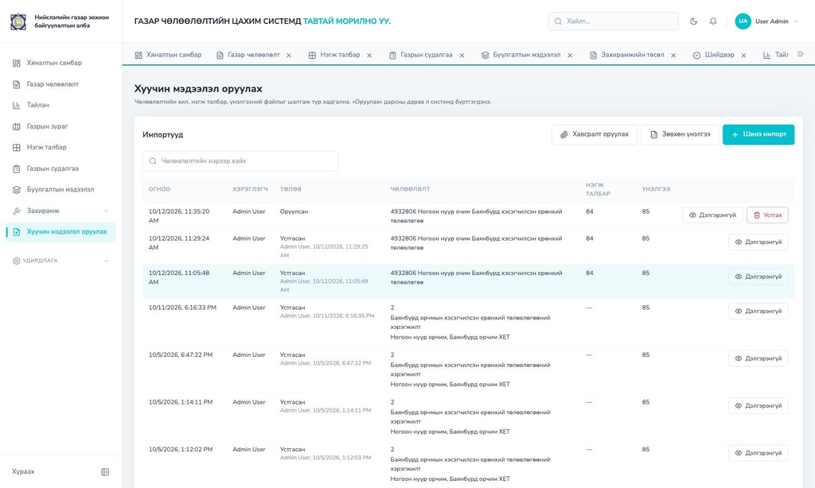

*Зураг 64. Хуучин мэдээлэл оруулах: импортын жагсаалт ба горимууд*

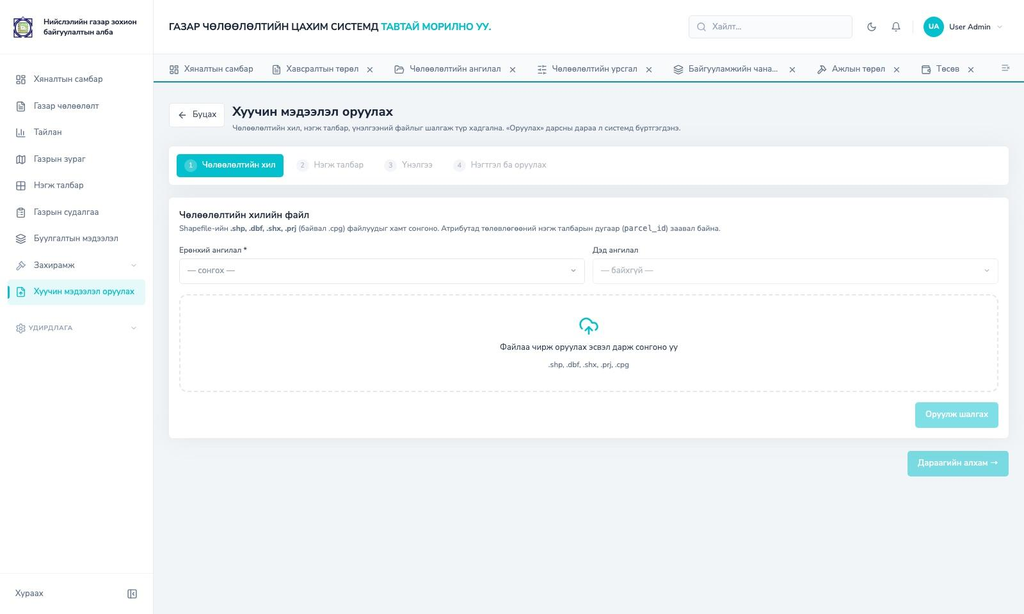

*Зураг 65. “Шинэ импорт”-ын 4 алхам: чөлөөлөлтийн хил, нэгж талбар, үнэлгээ, нэгтгэл ба оруулах*

## 10. АЖЛЫН ДААЛГАВРЫН БИЕЛЭЛТ

Ажлын даалгавар буюу системийн хөгжүүлэлтийн нарийвчилсан төлөвлөгөө нь задаргааны түвшний нийт 62 ажлаас бүрдэнэ. Үүнээс 1 ба 2-р бүлгийн хөгжүүлэлтийн 50 ажил бүгд хийгдсэн.

*Тооллогын арга: бүлэг, дэд бүлгийн гарчиг мөрүүдийг ажлын тоонд оруулаагүй, зөвхөн задаргаа ажлуудыг тоолсон. “Лог файл үүсгэх” (2.4.4.6) ажлыг аудит логийн системийн хэрэгжилтээр хийгдсэнд тооцов.*

| **Бүлэг** | **Ажлын тоо** |
| --- | --- |
| 1. Системийн бичиг баримтууд | 2 |
| 2. Систем хөгжүүлэлт | 48 |
| **Нийт** | **50** |

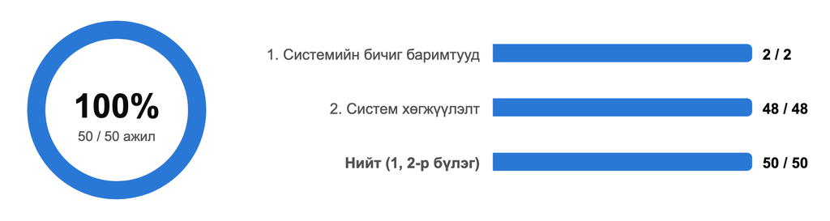

*Зураг 66. Ажлын даалгаврын хөгжүүлэлтийн ажлын гүйцэтгэл бүлгээр*

### 10.1 Ажлын даалгаврын ажил тус бүрийн хэрэгжилт (50)

Доорх хүснэгтэд ажлын даалгаварт бичигдсэн ажил бүрийг дугаар, нэрээр нь, хэрэгжилт ба тухайн ажлыг тайлбарласан бүлгийн дугаартай нь харуулав. Ажлын даалгаварт 2.2, 2.3 гэсэн дугаар хоёр өөр бүлэгт давхардан хэрэглэгдсэн тул бүлгийн гарчгаар нь ялгав.

[output not shown]

### 10.2 Туршилт, суурилуулалт, сургалт, төслийн хаалт (12)

Ажлын даалгаврын 3-6-р бүлгийн ажлууд нь хөгжүүлэлтийн бус, Захиалагчтай хамтарсан хуваарь, албан баримтаар гүйцэтгэгдэх зохион байгуулалтын ажил юм. Эдгээр ажлыг гүйцэтгэхэд шаардлагатай систем, орчин, баримт бичиг (техникийн тайлан, гарын авлага, Docker орчин, 771 автомат тест) бэлэн.

| **Бүлэг** | **Ажлууд** |
| --- | --- |
| **3. Туршилт /дотоод/** | 3.1 Туршилт хийх. 3.2 Туршилтаар илэрсэн алдааг засаж баталгаажуулах. 3.3 Туршилтаас гарсан санал хүсэлтүүдийг хэлэлцэх. |
| **4. Суурилуулалт** | 4.1 Судалгаа хийх. 4.2 Сүлжээ болон серверийн тохиргоо хийх. 4.3 Үйлдлийн систем, шаардлагатай програм хангамж, системийг суулгаж тохируулах. |
| **5. Сургалт** | 5.1 Сургалтын хөтөлбөр гаргаж Захиалагчаар батлуулах. 5.2 Сургалтын материал бэлтгэх. 5.3 Сургалт хийх. |
| **6. Төслийн хаалт** | 6.1 Бүх бичиг баримтуудыг хүлээлгэн өгөх. 6.2 Системийн эх код, мэдээллийн санг хүлээлгэн өгөх. 6.3 Туршилтаас гарсан санал хүсэлтүүдийг хэлэлцэх. |

### 10.3 Ажлын даалгаварт ороогүй боловч хэрэгжсэн нэмэлт ажлууд

Доорх ажлууд анхны 50 ажлын жагсаалтад тусгагдаагүй, харин хэрэглэгчийн туршилт, санал хүсэлтээр **нэмэлтээр** хийгдсэн.

- **3D газрын зургийн дүрслэл:** Чөлөөлөлтийн “Байршил” таб болон хяналтын самбарын газрын зурагт CesiumJS дээр суурилсан 2D/3D сонголт нэмэгдсэн. Одоо байгаа GeoServer давхаргууд (статус, хил, төлөвлөгөө) 3D дэлхийн бөмбөрцөг дээр бодит терраны өндөрлөгтэйгөөр давхарлагдан харагдана.
- **Excel-ээс үнэлгээ импортлох:** хөтөч дотор задлан шинжилж, SHA-256 хэшээр давхардлаас хамгаалдаг
- **Grafana систем:** Loki/Promtail-аар цуглуулсан бүх контейнерийн (frontend, backend, postgres) логийг нэгдсэн самбараар харах (9.16-д дэлгэрэнгүй)
- **Логжуулалт:** Frontend-д уншигдаагүй алдаа/алдааны хуудас (error.tsx, global-error.tsx) болон клиентийн логийг сервер рүү дамжуулах суваг нэмэгдсэн, харин backend-д slog бүтэцлэгдсэн JSON лог хэрэгжсэн (9.16-д дэлгэрэнгүй).
- **Гадны байгууллага буюу санхүүгийн албаны баталгаажуулалт, хяналтын хэсэг:** professional_org гишүүнчлэлийн шалгалт (RequireProfOrgMember), санхүүгийн мэргэжилтний батлах/буцаах урсгал нарийвчлагдсан
- **Төлөвлөгөөнд ороогүй хавсралтуудын хэвлэл болон утгын тохиргоонууд, уялдаа холбоо:** Эх хэвлэлийн 12 загвар, тэдгээрийн автомат бөглөлт, холбогдох баримт бичгийн төрлийн тохиргоотой уялдаа
- **Буулгалтын мэдээлэл:** буулгах байгууламжтай газрыг shapefile-аар оруулж, төлөв, захирамж, зурагтай нь хянах бие даасан модуль (9.18)
- **Газрын судалгаа:** чөлөөлөгдсөн газрын яндан, нойл, хажуу өрх, шилжин суурьшсан байршлын судалгааг нэгж талбар бүрээр бүртгэж нэгтгэх (9.17)
- **Он цагийн зураг:** нэгж талбарын явцыг сар сараар харуулж, самбарын тоог тухайн сарын байдлаар тооцох, мөн газрын зургийг сараар зурах (9.1.2)
- **Бүтэн дэлгэцийн хураангуй самбар:** газрын зураг дээр чөлөөлөлтийн явц, олговор, санхүүжилт, захирамжийн хураангуйг харуулах (9.1.1)
- **Санхүүгийн самбар:** санхүүгийн мэргэжилтэнд зориулсан мөнгөн дүнгийн самбар (9.1)
- **Ажлын зураг ба трас зураг хэвлэх:** төлөвийн тайлбар, давхарга сонгож A3, A4 хэмжээний PDF газрын зураг хэвлэх, мөн нэгж талбарын трас зургийг хэвлэж хавсралтад хадгалах (9.9.2, 9.5.6)
- **Төсөөллийн үнэлгээ:** суурь төлбөр, жишиг үнэ, итгэлцүүрээр нэгж талбарын урьдчилсан үнэлгээг тооцож түүхийг хадгалах (9.5.5)
- **Ашиглалтын хялбаршуулалт:** хөтчийн таб шиг хуудасны мөр, бүх жагсаалтыг баганаар эрэмбэлэх, 2010 оноос хойших олон он сонгох шүүлтүүр, Enter-ээр хайх, хажуугийн цэсийг хураах, нэвтрэх хуудасны хоёр таб
- **Нэмэлт хэвлэх загварууд:** газар дүйцүүлэх гэрээ, газар ба нөхөх олговрын гэрээ, гэрээ дүгнэсэн акт, ашиг сонирхлын зөрчилгүй тухай мэдүүлэг (2), байгууллагын мэдэгдэх хуудас, хяналтын картын хоёр дахь хувилбар (9.5.2)

## 11. НЭГДСЭН ДҮГНЭЛТ

### 11.1 Систем хийгдсэнээр гарсан үр дүн

- Бүх үе шат цаасан бус, нэгдсэн цахим урсгалд шилжсэн
- 3 бие даасан үнэлгээ зэрэгцээ явагдаж, workflow-оор баталгааждаг
- Орон зайн тооцоолол автоматжиж, зурган дээр бодит хугацаанд харагдана
- Гадны байгууллагууд тусгаарлагдсан порталтай (51 сувагтай /prof)
- 19 төрлийн албан баримт, 4 төрлийн Excel тайлан, ажлын зураг ба трас зураг автоматаар үүсдэг
- ГУС-ийн 5 дэд системтэй бодит холболт ажиллаж, нэгж талбарын мэдээлэл 19 дуудлагаар татагдана
- УБЕГ-ийн газар өмчлөл ХУР (XYP) гарцаар татагдаж, нэгж талбарын эзэмшлийн зураг бүрэн болсон
- Мэдэгдэх хуудас, албан бичиг, нийгэм, эдийн засгийн судалгаа цаасан бус хэлбэрээр иргэнд имэйл ба E-Mongolia-гаар хүрч, огноотой түүх үлддэг
- Гадаад системд хоёр гарц нээгдсэн: API key-тэй нөхөх олговрын REST API ба эрх шалгахгүй нээлттэй GIS давхарга (явцын өнгө, дүүргийн шүүлт)
- Газрын зургийн суурь (агаар, сансрын) зургийг код засалгүй, дэлгэцээс тохируулдаг болсон
- 2010-2025 оны нөхөх олговортойгоор чөлөөлөгдсөн газрын мэдээллийг шалгаж оруулах, алдааг буцаах хэрэгсэлтэй болсон
- Нэгж талбарын явцыг сар сараар нь он цагийн зургаар харж, удирдлагын хурлыг бүтэн дэлгэцийн хураангуй самбараар хийх боломжтой болсон
- Буулгах байгууламжтай газар, чөлөөлөгдсөн газрын нийгмийн нөхцөл байдал (газрын судалгаа) тусдаа бүртгэлтэй болсон
- Ажлын урсгал, төлөвийн өнгө, дүрэм, шилжилтийн заавал хавсралтыг администратор програм засахгүйгээр тохируулдаг болсон
- Ажлын даалгаврын хөгжүүлэлтийн 50 ажил бүгд хийгдсэн (100%)

### 11.2 Давуу талууд

- **Цэвэр давхаргажилт:** өргөтгөлд тэсвэртэй, тестлэгдэхүйц бүтэц
- **Гүн хамгаалалт:** 4 давхар эрхийн шалгалт
- **Workflow тохиргоогоор:** процесс өөрчлөгдөхөд код засалтгүй
- **Бүрэн аудитын мөр:** өөрчлөлт бүр түүхтэй
- **Нээлттэй эхийн стек:** лицензийн зардалгүй
- **Гадаад холболт 27/27:** ГУС, ХУР (УБЕГ), E-Mongolia. Гадагш гаргах гарцууд deny-by-default зарчмаар хамгаалагдсан.

## ХАВСРАЛТ. НЭР ТОМЬЁОНЫ ТАЙЛБАР

Тайланд ашигласан мэргэжлийн нэр томьёоны энгийн тайлбар:

| **Нэр томьёо** | **Энгийн тайлбар** |
| --- | --- |
| **Frontend / Backend** | Frontend нь хэрэглэгчийн хөтөч дээр харагдах вэб хуудаснууд, харин Backend нь ард талд ажиллаж, өгөгдөл боловсруулж хадгалдаг сервер програм |
| **API, endpoint** | Програмууд хоорондоо мэдээлэл солилцох гэрээт “цонх”. Endpoint нь тухайн нэг үйлчилгээний хаяг (жишээ: талбарын жагсаалт авах хаяг) |
| **REST** | API зохион байгуулах түгээмэл стандарт бөгөөд унших/нэмэх/засах/устгах үйлдлүүд тус тусын хаягтай байдаг |
| **Өгөгдлийн сан (PostgreSQL)** | Бүх мэдээллийг хүснэгт хэлбэрээр найдвартай хадгалдаг сан |
| **PostGIS** | Өгөгдлийн санд газарзүйн хэлбэр (талбарын хил г.м.) хадгалж, талбай, давхцал зэргийг тооцох боломж олгодог өргөтгөл |
| **GeoServer, WMS/WFS** | Газрын зургийн давхаргуудыг вэбээр түгээдэг сервер. WMS нь зураг хэлбэрээр, WFS нь өгөгдөл хэлбэрээр өгдөг стандартууд |
| **Migration** | Өгөгдлийн сангийн бүтцийн өөрчлөлт бүрийг дугаарлаж хадгалсан “алхам”. Шинэ орчинд сан ямар ч үед мөр дараалан ижил бүтэцтэй босдог |
| **JWT, token** | Нэвтэрсэн хэрэглэгчийг таниулах цахим “үнэмлэх” бөгөөд хүсэлт бүрт дагалдаж, хугацаа дуусахад шинэчлэгдэнэ |
| **bcrypt, SHA-256** | Нууц үг болон файлыг математик аргаар “хурууны хээ” болгох аргууд. Ингэснээр нууц үг ил хадгалагдахгүй, файлын давхардал илэрдэг |
| **RBAC, permission** | Ролид суурилсан эрхийн удирдлага бөгөөд хэрэглэгч бүр ролийнхоо хүрээнд л үйлдэл хийж чадна (жишээ: land:update нь чөлөөлөлт засах эрх) |
| **Workflow** | Ажлын урсгал буюу аль төлөвөөс аль төлөв рүү, ямар нөхцөлтэйгөөр шилжиж болохыг урьдчилан тогтоосон дүрэм |
| **SSE (Server-Sent Events)** | Сервер хөтөч рүү мэдээллийг хүсэлт хүлээлгүйгээр өөрөө “түлхэж” илгээдэг холболт бөгөөд мэдэгдэл бодит цагт ирэх үндэс болдог |
| **Аудит лог** | Хэн, хэзээ, хаанаас (IP), юу өөрчилснийг бүртгэдэг хөндөгдөшгүй тэмдэглэл бөгөөд хяналт шалгалтын эх сурвалж болдог |
| **Shapefile, WKT** | Газарзүйн хилийн мэдээллийг хадгалах түгээмэл файлын форматууд |
| **ERD** | Өгөгдлийн сангийн хүснэгтүүд ба тэдгээрийн холбоог харуулсан бүтцийн зураг |
| **Docker** | Програмыг орчноос нь хамааралгүй, нэг командаар асаадаг “сав” технологи |
| **Clean Architecture** | Кодыг үе давхаргаар (хүлээн авах, боловсруулах, хадгалах) тусгаарлан зохион байгуулах арга бөгөөд засвар, өргөтгөлд тэсвэртэй |
| **Swagger** | API-ийн бүх үйлчилгээний цэгийг жагсааж, туршиж үзэх боломжтой автомат баримтжуулалт |
| **CQL шүүлт** | Газрын зургийн давхаргаас нөхцөлөөр (он, чөлөөлөлт г.м.) шүүж харуулах хэллэг |
| **Cache (кэш)** | Олон дахин уншигддаг мэдээллийг түр санахад хадгалж хурдасгах арга |

*Энэхүү тайланг government-frontend болон government repo-гийн эх кодын шинжилгээнд үндэслэн үүсгэв. Тоон үзүүлэлтүүд нь эх кодоос шууд тоологдсон болно.*